# Business Intelligence & Customer Analytics Dashboard

#### Name: Tawakalt Oyekemi O.

#### Email: tawakaltoyeleso01@gmail.com

## Goal

Build a star-schema data warehouse, automated ETL workflows, and create interactive dashboards analyzing revenue trends, product performance, and customer behavior, enabling data-driven decision-making through KPI tracking and advanced visualizations.

### Define Business Question

1. How has revenue changed over time?
2. Which products contribute the most revenue?
3. Which countries generate the highest sales?
4. Who are the most valuable customers?
5. How frequently do customers make purchases?
6. What is the average order value?
7. What is the customer lifetime value distribution?
8. Which customer segments generate the most revenue?

### Dataset URL: [Open Project Repository](https://archive.ics.uci.edu/dataset/352/online+retail)

### Technology Stack

1. Data Storage : PostgreSQL
2. Data Processing : Python Pandas SQLAlchemy
3. Dashboard Tool : Microsoft PowerBi

```python
import pandas as pd
import numpy as np
import matplotlib.pyplot as plt
```

```python
# Load Dataset

sales_df = pd.read_excel("C:/Users/Tawakalt.Oyeleso/Desktop/Tawakalt Docs/Projects/Online Retail/online+retail/Online Retail.xlsx")
```

```python
# Check the column

columns = sales_df.head()
print(columns)
```

```
  InvoiceNo StockCode                          Description  Quantity  \
0    536365    85123A   WHITE HANGING HEART T-LIGHT HOLDER         6
1    536365     71053                  WHITE METAL LANTERN         6
2    536365    84406B       CREAM CUPID HEARTS COAT HANGER         8
3    536365    84029G  KNITTED UNION FLAG HOT WATER BOTTLE         6
4    536365    84029E       RED WOOLLY HOTTIE WHITE HEART.         6

          InvoiceDate  UnitPrice  CustomerID         Country
0 2010-12-01 08:26:00       2.55     17850.0  United Kingdom
1 2010-12-01 08:26:00       3.39     17850.0  United Kingdom
2 2010-12-01 08:26:00       2.75     17850.0  United Kingdom
3 2010-12-01 08:26:00       3.39     17850.0  United Kingdom
4 2010-12-01 08:26:00       3.39     17850.0  United Kingdom
```

```python
sales_df.head(15)
```

|  | InvoiceNo | StockCode | Description | Quantity | InvoiceDate | UnitPrice | CustomerID | Country |
| --- | --- | --- | --- | --- | --- | --- | --- | --- |
| 0 | 536365 | 85123A | WHITE HANGING HEART T-LIGHT HOLDER | 6 | 2010-12-01 08:26:00 | 2.55 | 17850.0 | United Kingdom |
| 1 | 536365 | 71053 | WHITE METAL LANTERN | 6 | 2010-12-01 08:26:00 | 3.39 | 17850.0 | United Kingdom |
| 2 | 536365 | 84406B | CREAM CUPID HEARTS COAT HANGER | 8 | 2010-12-01 08:26:00 | 2.75 | 17850.0 | United Kingdom |
| 3 | 536365 | 84029G | KNITTED UNION FLAG HOT WATER BOTTLE | 6 | 2010-12-01 08:26:00 | 3.39 | 17850.0 | United Kingdom |
| 4 | 536365 | 84029E | RED WOOLLY HOTTIE WHITE HEART. | 6 | 2010-12-01 08:26:00 | 3.39 | 17850.0 | United Kingdom |
| 5 | 536365 | 22752 | SET 7 BABUSHKA NESTING BOXES | 2 | 2010-12-01 08:26:00 | 7.65 | 17850.0 | United Kingdom |
| 6 | 536365 | 21730 | GLASS STAR FROSTED T-LIGHT HOLDER | 6 | 2010-12-01 08:26:00 | 4.25 | 17850.0 | United Kingdom |
| 7 | 536366 | 22633 | HAND WARMER UNION JACK | 6 | 2010-12-01 08:28:00 | 1.85 | 17850.0 | United Kingdom |
| 8 | 536366 | 22632 | HAND WARMER RED POLKA DOT | 6 | 2010-12-01 08:28:00 | 1.85 | 17850.0 | United Kingdom |
| 9 | 536367 | 84879 | ASSORTED COLOUR BIRD ORNAMENT | 32 | 2010-12-01 08:34:00 | 1.69 | 13047.0 | United Kingdom |
| 10 | 536367 | 22745 | POPPY'S PLAYHOUSE BEDROOM | 6 | 2010-12-01 08:34:00 | 2.10 | 13047.0 | United Kingdom |
| 11 | 536367 | 22748 | POPPY'S PLAYHOUSE KITCHEN | 6 | 2010-12-01 08:34:00 | 2.10 | 13047.0 | United Kingdom |
| 12 | 536367 | 22749 | FELTCRAFT PRINCESS CHARLOTTE DOLL | 8 | 2010-12-01 08:34:00 | 3.75 | 13047.0 | United Kingdom |
| 13 | 536367 | 22310 | IVORY KNITTED MUG COSY | 6 | 2010-12-01 08:34:00 | 1.65 | 13047.0 | United Kingdom |
| 14 | 536367 | 84969 | BOX OF 6 ASSORTED COLOUR TEASPOONS | 6 | 2010-12-01 08:34:00 | 4.25 | 13047.0 | United Kingdom |

```python
sales_df.info()
```

```
<class 'pandas.core.frame.DataFrame'>
RangeIndex: 541909 entries, 0 to 541908
Data columns (total 8 columns):
 #   Column       Non-Null Count   Dtype
---  ------       --------------   -----
 0   InvoiceNo    541909 non-null  object
 1   StockCode    541909 non-null  object
 2   Description  540455 non-null  object
 3   Quantity     541909 non-null  int64
 4   InvoiceDate  541909 non-null  datetime64[ns]
 5   UnitPrice    541909 non-null  float64
 6   CustomerID   406829 non-null  float64
 7   Country      541909 non-null  object
dtypes: datetime64[ns](1), float64(2), int64(1), object(4)
memory usage: 33.1+ MB
```

```python
sales_df.shape
```

```
(541909, 8)
```

```python
sales_df.isnull().sum()
```

```
InvoiceNo           0
StockCode           0
Description      1454
Quantity            0
InvoiceDate         0
UnitPrice           0
CustomerID     135080
Country             0
dtype: int64
```

```python
sales_df.duplicated().sum()
```

```
np.int64(5268)
```

```python
sales_df.describe()
```

|  | Quantity | InvoiceDate | UnitPrice | CustomerID |
| --- | --- | --- | --- | --- |
| count | 541909.000000 | 541909 | 541909.000000 | 406829.000000 |
| mean | 9.552250 | 2011-07-04 13:34:57.156386048 | 4.611114 | 15287.690570 |
| min | -80995.000000 | 2010-12-01 08:26:00 | -11062.060000 | 12346.000000 |
| 25% | 1.000000 | 2011-03-28 11:34:00 | 1.250000 | 13953.000000 |
| 50% | 3.000000 | 2011-07-19 17:17:00 | 2.080000 | 15152.000000 |
| 75% | 10.000000 | 2011-10-19 11:27:00 | 4.130000 | 16791.000000 |
| max | 80995.000000 | 2011-12-09 12:50:00 | 38970.000000 | 18287.000000 |
| std | 218.081158 | NaN | 96.759853 | 1713.600303 |

```python
print(sales_df.columns)
```

```
Index(['InvoiceNo', 'StockCode', 'Description', 'Quantity', 'InvoiceDate',
       'UnitPrice', 'CustomerID', 'Country'],
      dtype='object')
```

```python
for col in sales_df.columns:

    print(f"\n{'='*70}")
    print(f"Column: {col}")
    print(f"{'='*70}")

    print("Datatype:", sales_df[col].dtype)
    print("Missing:", sales_df[col].isna().sum())
    print("Missing %:", round(sales_df[col].isna().mean() * 100, 2))
    print("Unique:", sales_df[col].nunique())

     # Numeric columns
    if pd.api.types.is_numeric_dtype(sales_df[col]):

        print("\nSummary Statistics:")
        print(sales_df[col].describe())

        print("\nNegative Values:",
              (sales_df[col] < 0).sum())

        print("Zero Values:",
              (sales_df[col] == 0).sum())

    # Datetime columns
    elif pd.api.types.is_datetime64_any_dtype(sales_df[col]):

        print("\nDate Range:")
        print("Min:", sales_df[col].min())
        print("Max:", sales_df[col].max())

    # Text / Categorical columns
    else:

        print("\nTop Values:")
        print(sales_df[col].value_counts(dropna=False).head(10))
```

```
======================================================================
Column: InvoiceNo
======================================================================
Datatype: object
Missing: 0
Missing %: 0.0
Unique: 25900

Top Values:
InvoiceNo
573585    1114
581219     749
581492     731
580729     721
558475     705
579777     687
581217     676
537434     675
580730     662
538071     652
Name: count, dtype: int64

======================================================================
Column: StockCode
======================================================================
Datatype: object
Missing: 0
Missing %: 0.0
Unique: 4070

Top Values:
StockCode
85123A    2313
22423     2203
85099B    2159
47566     1727
20725     1639
84879     1502
22720     1477
22197     1476
```

[output cut: 110 more lines]

```
Unique: 38

Top Values:
Country
United Kingdom    495478
Germany             9495
France              8557
EIRE                8196
Spain               2533
Netherlands         2371
Belgium             2069
Switzerland         2002
Portugal            1519
Australia           1259
Name: count, dtype: int64
```

#### Data Quality Findings

InvoiceNo

- No missing values
- 25,900 unique entries

Status: Needs Investigation

Questions: Are invoice numbers unique?

StockCode

- No missing values
- 4,070 unique values

Status: Needs Investigation

Questions:

- Are all StockCodes products?
- Are there administrative codes such as:
  - POST
  - D
  - M
  - BANK CHARGES

Description

- 1,454 missing values
- Represents 0.27% of dataset
- 4,223 unique values

Status: Minor issue

Reason: Very low percentage missing

Quantity

- No missing values
- 722 unique values
- 10,624 negative values

Status: Major issue

Questions:

- What do negative quantities represent?
- Are they returns?
- Are they cancellations?
- Why is minimum = -80,995 and maximum = 80,995?

InvoiceDate

- No missing values
- Covers approximately one year
- 23,260 unique timestamps

Status: Clean

UnitPrice

- No missing values
- 1,630 unique values
- 2 negative values
- 2,515 zero values

Status: Moderate issue

Reason: The bigger concern is 2515 zero prices rather than 2 negative prices.

CustomerID

- 135,080 missing values
- Represents approximately 25% of dataset
- 4,372 unique customers

Status: Major issue

Reason: Cannot perform:

- Customer segmentation
- Customer Lifetime Value
- RFM analysis on records without CustomerID.

Country

- 38 unique countries
- No missing values

Status: Clean

```python
#identifying the content of unique values

for col in sales_df.columns:
    print(f"\n{'='*60}")
    print(f"Column: {col}")
    print(f"{'='*60}")

    print(sales_df[col].value_counts(dropna=False).head(20))
```

```
============================================================
Column: InvoiceNo
============================================================
InvoiceNo
573585    1114
581219     749
581492     731
580729     721
558475     705
579777     687
581217     676
537434     675
580730     662
538071     652
580367     650
580115     645
581439     635
580983     629
578344     622
538349     620
578347     606
537638     601
537237     597
536876     593
Name: count, dtype: int64

============================================================
Column: StockCode
============================================================
StockCode
85123A    2313
22423     2203
85099B    2159
47566     1727
20725     1639
84879     1502
22720     1477
22197     1476
21212     1385
20727     1350
```

[output cut: 152 more lines]

```
Belgium              2069
Switzerland          2002
Portugal             1519
Australia            1259
Norway               1086
Italy                 803
Channel Islands       758
Finland               695
Cyprus                622
Sweden                462
Unspecified           446
Austria               401
Denmark               389
Japan                 358
Name: count, dtype: int64
```

### Investigating InvoiceNo

```python
# identifying the content of unique values in 'InvoiceNo' column

sales_df['InvoiceNo'].astype(str).str[0].value_counts()
```

```
InvoiceNo
5    532618
C      9288
A         3
Name: count, dtype: int64
```

##### Why do some start with letters?

##### What does C mean? If this code starts with letter 'C', it indicates a cancellation.

##### What does A mean? Very rare. Need Investigation

```python
# Understanding the meaning of 'A'

sales_df[sales_df['InvoiceNo'].astype(str).str.startswith('A')]
```

|  | InvoiceNo | StockCode | Description | Quantity | InvoiceDate | UnitPrice | CustomerID | Country |
| --- | --- | --- | --- | --- | --- | --- | --- | --- |
| 299982 | A563185 | B | Adjust bad debt | 1 | 2011-08-12 14:50:00 | 11062.06 | NaN | United Kingdom |
| 299983 | A563186 | B | Adjust bad debt | 1 | 2011-08-12 14:51:00 | -11062.06 | NaN | United Kingdom |
| 299984 | A563187 | B | Adjust bad debt | 1 | 2011-08-12 14:52:00 | -11062.06 | NaN | United Kingdom |

##### What does A mean?

It means adjusted bad debt.

```python
# Are all invoice numbers the same length?

sales_df['InvoiceNo'].astype(str).str.len().value_counts()
```

```
InvoiceNo
6    532618
7      9291
Name: count, dtype: int64
```

```python
sales_df[sales_df['InvoiceNo'].astype(str).str.len() == 7]['InvoiceNo'].head()
```

```
141    C536379
154    C536383
235    C536391
236    C536391
237    C536391
Name: InvoiceNo, dtype: object
```

### InvoiceNo Findings

- No missing values.
- 25,900 unique invoice numbers.
- InvoiceNo are stored as text (object datatype).
- Most invoice numbers contain 6 characters.
- A smaller group of invoice numbers contain 7 characters.
- 9,288 invoices begin with C, indicating cancelled transactions.
- 3 invoices begin with A, indicating adjusted bad debt transactions.
- However, in the Online Retail dataset, the 7-character invoices are typically the ones beginning with C and A

Status: Requires investigation and business decision.

Recommended Action:

- Keep numeric invoices.
- Exclude C (Cancelled Transactions) invoices from revenue and sales analysis.
- Exclude A (Adjusted Bad Debt) invoices from revenue and sales analysis.

### Conclusion

Certain Invoice number represent cancellations or bad debt and should be excluded from revenue based analyses.

### Investigating StockCode

```python
#Identifying common StockCodes

sales_df['StockCode'].value_counts().head(50)
```

```
StockCode
85123A    2313
22423     2203
85099B    2159
47566     1727
20725     1639
84879     1502
22720     1477
22197     1476
21212     1385
20727     1350
22383     1348
22457     1280
23203     1267
POST      1256
```

[output cut: 37 more lines]

```python
# Identifying codes that contains letters

sales_df[
    sales_df['StockCode'].astype(str).str.contains('[A-Za-z]', regex = True, na=False)]['StockCode'].drop_duplicates().sort_values()
```

```
5451            10123C
150159          10123G
12492           10124A
3973            10124G
40154           15044A
              ...
44794     gift_0001_20
44725     gift_0001_30
38248     gift_0001_40
42057     gift_0001_50
40383                m
Name: StockCode, Length: 1124, dtype: object
```

```python
# separate product codes from administrative codes

sales_df[
    sales_df['StockCode'].astype(str).str.contains('[A-Za-z]', regex = True, na=False)]['StockCode'].value_counts()
```

```
StockCode
85123A    2313
85099B    2159
POST      1256
85099C     960
82494L     943
          ...
84845D       1
82545A       1
84251F       1
35603B       1
47591b       1
Name: count, Length: 1124, dtype: int64
```

```python
#check for all special codes

sales_df[~sales_df['StockCode'].astype(str).str.match(r'^\d+[A-Za-z]?$')]['StockCode'].value_counts()
```

```
StockCode
POST            1256
DOT              710
M                571
15056BL          326
C2               144
D                 77
S                 63
15056bl           62
BANK CHARGES      37
AMAZONFEE         34
CRUK              16
DCGSSGIRL         13
DCGSSBOY          11
gift_0001_20      10
gift_0001_10       9
gift_0001_30       8
DCGS0003           5
gift_0001_50       4
PADS               4
B                  3
gift_0001_40       3
DCGS0070           2
DCGS0076           2
DCGS0069           2
DCGS0067           1
79323GR            1
DCGS0066P          1
DCGS0071           1
DCGS0068           1
DCGS0055           1
DCGS0073           1
DCGS0004           1
DCGS0057           1
DCGS0074           1
DCGS0072           1
m                  1
79323LP            1
Name: count, dtype: int64
```

### Questions

- Are all StockCodes products?
- Do some StockCodes represent administrative transactions?
- Should non-product StockCodes be excluded from product performance analysis?

```python
# Inestigating Special Codes
sales_df[sales_df['StockCode'] == 'POST']
```

|  | InvoiceNo | StockCode | Description | Quantity | InvoiceDate | UnitPrice | CustomerID | Country |
| --- | --- | --- | --- | --- | --- | --- | --- | --- |
| 45 | 536370 | POST | POSTAGE | 3 | 2010-12-01 08:45:00 | 18.0 | 12583.0 | France |
| 386 | 536403 | POST | POSTAGE | 1 | 2010-12-01 11:27:00 | 15.0 | 12791.0 | Netherlands |
| 1123 | 536527 | POST | POSTAGE | 1 | 2010-12-01 13:04:00 | 18.0 | 12662.0 | Germany |
| 5073 | 536840 | POST | POSTAGE | 1 | 2010-12-02 18:27:00 | 18.0 | 12738.0 | Germany |
| 5258 | 536852 | POST | POSTAGE | 1 | 2010-12-03 09:51:00 | 18.0 | 12686.0 | France |
| ... | ... | ... | ... | ... | ... | ... | ... | ... |
| 541198 | 581493 | POST | POSTAGE | 1 | 2011-12-09 10:10:00 | 15.0 | 12423.0 | Belgium |
| 541216 | 581494 | POST | POSTAGE | 2 | 2011-12-09 10:13:00 | 18.0 | 12518.0 | Germany |
| 541730 | 581570 | POST | POSTAGE | 1 | 2011-12-09 11:59:00 | 18.0 | 12662.0 | Germany |
| 541767 | 581574 | POST | POSTAGE | 2 | 2011-12-09 12:09:00 | 18.0 | 12526.0 | Germany |
| 541768 | 581578 | POST | POSTAGE | 3 | 2011-12-09 12:16:00 | 18.0 | 12713.0 | Germany |

1256 rows × 8 columns

```python
sales_df[sales_df['StockCode'] == 'D']
```

|  | InvoiceNo | StockCode | Description | Quantity | InvoiceDate | UnitPrice | CustomerID | Country |
| --- | --- | --- | --- | --- | --- | --- | --- | --- |
| 141 | C536379 | D | Discount | -1 | 2010-12-01 09:41:00 | 27.50 | 14527.0 | United Kingdom |
| 9038 | C537164 | D | Discount | -1 | 2010-12-05 13:21:00 | 29.29 | 14527.0 | United Kingdom |
| 14498 | C537597 | D | Discount | -1 | 2010-12-07 12:34:00 | 281.00 | 15498.0 | United Kingdom |
| 19392 | C537857 | D | Discount | -1 | 2010-12-08 16:00:00 | 267.12 | 17340.0 | United Kingdom |
| 31134 | C538897 | D | Discount | -1 | 2010-12-15 09:14:00 | 5.76 | 16422.0 | United Kingdom |
| ... | ... | ... | ... | ... | ... | ... | ... | ... |
| 479868 | C577227 | D | Discount | -1 | 2011-11-18 12:06:00 | 19.82 | 14527.0 | United Kingdom |
| 479869 | C577227 | D | Discount | -1 | 2011-11-18 12:06:00 | 16.76 | 14527.0 | United Kingdom |
| 493613 | C578239 | D | Discount | -1 | 2011-11-23 12:29:00 | 26.33 | 14912.0 | Italy |
| 516221 | C579884 | D | Discount | -1 | 2011-11-30 17:34:00 | 20.53 | 14527.0 | United Kingdom |
| 516455 | C579908 | D | Discount | -1 | 2011-12-01 08:49:00 | 28.68 | 14527.0 | United Kingdom |

77 rows × 8 columns

```python
sales_df[sales_df['StockCode'] == 'M']
```

|  | InvoiceNo | StockCode | Description | Quantity | InvoiceDate | UnitPrice | CustomerID | Country |
| --- | --- | --- | --- | --- | --- | --- | --- | --- |
| 2239 | 536569 | M | Manual | 1 | 2010-12-01 15:35:00 | 1.25 | 16274.0 | United Kingdom |
| 2250 | 536569 | M | Manual | 1 | 2010-12-01 15:35:00 | 18.95 | 16274.0 | United Kingdom |
| 5684 | 536865 | M | Manual | 1 | 2010-12-03 11:28:00 | 2.55 | NaN | United Kingdom |
| 6798 | 536981 | M | Manual | 2 | 2010-12-03 14:26:00 | 0.85 | 14723.0 | United Kingdom |
| 7976 | 537077 | M | Manual | 12 | 2010-12-05 11:59:00 | 0.42 | 17062.0 | United Kingdom |
| ... | ... | ... | ... | ... | ... | ... | ... | ... |
| 531432 | 580956 | M | Manual | 4 | 2011-12-06 14:23:00 | 1.25 | 17841.0 | United Kingdom |
| 533082 | C581009 | M | Manual | -1 | 2011-12-07 09:15:00 | 125.00 | 16971.0 | United Kingdom |
| 534308 | C581145 | M | Manual | -1 | 2011-12-07 13:48:00 | 9.95 | 17490.0 | United Kingdom |
| 538321 | 581405 | M | Manual | 3 | 2011-12-08 13:50:00 | 0.42 | 13521.0 | United Kingdom |
| 541541 | C581499 | M | Manual | -1 | 2011-12-09 10:28:00 | 224.69 | 15498.0 | United Kingdom |

571 rows × 8 columns

```python
sales_df[sales_df['StockCode'] == 'm']
```

|  | InvoiceNo | StockCode | Description | Quantity | InvoiceDate | UnitPrice | CustomerID | Country |
| --- | --- | --- | --- | --- | --- | --- | --- | --- |
| 40383 | 539736 | m | Manual | 1 | 2010-12-21 15:18:00 | 2.55 | NaN | United Kingdom |

```python
sales_df[sales_df['StockCode'] == 'BANK CHARGES']
```

|  | InvoiceNo | StockCode | Description | Quantity | InvoiceDate | UnitPrice | CustomerID | Country |
| --- | --- | --- | --- | --- | --- | --- | --- | --- |
| 4406 | 536779 | BANK CHARGES | Bank Charges | 1 | 2010-12-02 15:08:00 | 15.000 | 15823.0 | United Kingdom |
| 14435 | C537572 | BANK CHARGES | Bank Charges | -1 | 2010-12-07 12:00:00 | 95.380 | NaN | United Kingdom |
| 28992 | C538680 | BANK CHARGES | Bank Charges | -1 | 2010-12-13 17:10:00 | 966.920 | NaN | United Kingdom |
| 62508 | 541505 | BANK CHARGES | Bank Charges | 1 | 2011-01-18 15:58:00 | 15.000 | 15939.0 | United Kingdom |
| 64573 | C541653 | BANK CHARGES | Bank Charges | -1 | 2011-01-20 11:50:00 | 1050.150 | NaN | United Kingdom |
| 90558 | C544049 | BANK CHARGES | Bank Charges | -1 | 2011-02-15 12:39:00 | 566.370 | NaN | United Kingdom |
| 96675 | C544575 | BANK CHARGES | Bank Charges | -1 | 2011-02-21 13:58:00 | 134.760 | NaN | United Kingdom |
| 96676 | C544576 | BANK CHARGES | Bank Charges | -1 | 2011-02-21 14:01:00 | 149.160 | NaN | United Kingdom |
| 96715 | C544584 | BANK CHARGES | Bank Charges | -1 | 2011-02-21 14:52:00 | 109.840 | NaN | United Kingdom |
| 112233 | C545887 | BANK CHARGES | Bank Charges | -1 | 2011-03-07 15:54:00 | 326.680 | NaN | United Kingdom |
| 124025 | C546943 | BANK CHARGES | Bank Charges | -1 | 2011-03-18 11:11:00 | 56.930 | NaN | United Kingdom |
| 152966 | 549717 | BANK CHARGES | Bank Charges | 1 | 2011-04-11 14:56:00 | 15.000 | 14606.0 | United Kingdom |
| 166515 | C550932 | BANK CHARGES | Bank Charges | -1 | 2011-04-21 15:12:00 | 475.690 | NaN | United Kingdom |
| 175275 | 551945 | BANK CHARGES | Bank Charges | 1 | 2011-05-05 11:09:00 | 15.000 | 16714.0 | United Kingdom |
| 181258 | C552458 | BANK CHARGES | Bank Charges | -1 | 2011-05-09 14:41:00 | 440.290 | NaN | United Kingdom |
| 193136 | C553511 | BANK CHARGES | Bank Charges | -1 | 2011-05-17 13:49:00 | 86.900 | NaN | United Kingdom |
| 193444 | C553528 | BANK CHARGES | Bank Charges | -1 | 2011-05-17 14:58:00 | 82.730 | NaN | United Kingdom |
| 227400 | C556874 | BANK CHARGES | Bank Charges | -1 | 2011-06-15 11:49:00 | 464.520 | NaN | United Kingdom |
| 242465 | C558349 | BANK CHARGES | Bank Charges | -1 | 2011-06-28 14:50:00 | 82.890 | NaN | United Kingdom |
| 273311 | C560823 | BANK CHARGES | Bank Charges | -1 | 2011-07-21 11:22:00 | 21.900 | NaN | United Kingdom |
| 303275 | C563535 | BANK CHARGES | Bank Charges | -1 | 2011-08-17 11:38:00 | 612.460 | NaN | United Kingdom |
| 313427 | C564494 | BANK CHARGES | Bank Charges | -1 | 2011-08-25 14:20:00 | 83.830 | NaN | United Kingdom |
| 313461 | C564498 | BANK CHARGES | Bank Charges | -1 | 2011-08-25 14:22:00 | 77.630 | NaN | United Kingdom |
| 327921 | 565735 | BANK CHARGES | Bank Charges | 1 | 2011-09-06 12:25:00 | 15.000 | 16904.0 | United Kingdom |
| 345020 | C567136 | BANK CHARGES | Bank Charges | -1 | 2011-09-16 14:27:00 | 366.270 | NaN | United Kingdom |
| 361740 | 568375 | BANK CHARGES | Bank Charges | 1 | 2011-09-26 17:01:00 | 15.000 | 13405.0 | United Kingdom |
| 361741 | 568375 | BANK CHARGES | Bank Charges | 1 | 2011-09-26 17:01:00 | 0.001 | 13405.0 | United Kingdom |
| 388729 | C570454 | BANK CHARGES | Bank Charges | -1 | 2011-10-10 15:21:00 | 472.770 | NaN | United Kingdom |
| 389027 | C570463 | BANK CHARGES | Bank Charges | -1 | 2011-10-10 15:59:00 | 49.650 | NaN | United Kingdom |
| 407618 | 571900 | BANK CHARGES | Bank Charges | 1 | 2011-10-19 14:26:00 | 15.000 | 13263.0 | United Kingdom |
| 414146 | C572346 | BANK CHARGES | Bank Charges | -1 | 2011-10-24 10:58:00 | 49.650 | NaN | United Kingdom |
| 431351 | 573586 | BANK CHARGES | Bank Charges | 1 | 2011-10-31 14:48:00 | 15.000 | 14704.0 | United Kingdom |
| 440745 | 574546 | BANK CHARGES | Bank Charges | 1 | 2011-11-04 14:59:00 | 15.000 | 13651.0 | United Kingdom |
| 481152 | C577342 | BANK CHARGES | Bank Charges | -1 | 2011-11-18 15:11:00 | 490.060 | NaN | United Kingdom |
| 481153 | C577343 | BANK CHARGES | Bank Charges | -1 | 2011-11-18 15:13:00 | 27.210 | NaN | United Kingdom |
| 506357 | 579137 | BANK CHARGES | Bank Charges | 1 | 2011-11-28 12:51:00 | 15.000 | 14704.0 | United Kingdom |
| 534008 | 581127 | BANK CHARGES | Bank Charges | 1 | 2011-12-07 12:45:00 | 15.000 | 16271.0 | United Kingdom |

```python
#understanding what "gift..." stands for

sales_df[
    sales_df['StockCode']
    .str.contains('gift', case=False, na=False)
]
```

|  | InvoiceNo | StockCode | Description | Quantity | InvoiceDate | UnitPrice | CustomerID | Country |
| --- | --- | --- | --- | --- | --- | --- | --- | --- |
| 38248 | 539492 | gift_0001_40 | Dotcomgiftshop Gift Voucher £40.00 | 1 | 2010-12-20 10:14:00 | 34.04 | NaN | United Kingdom |
| 42057 | 539958 | gift_0001_50 | Dotcomgiftshop Gift Voucher £50.00 | 1 | 2010-12-23 13:26:00 | 42.55 | NaN | United Kingdom |
| 44725 | 540238 | gift_0001_30 | Dotcomgiftshop Gift Voucher £30.00 | 1 | 2011-01-05 14:44:00 | 25.53 | NaN | United Kingdom |
| 44794 | 540238 | gift_0001_20 | Dotcomgiftshop Gift Voucher £20.00 | 1 | 2011-01-05 14:44:00 | 17.02 | NaN | United Kingdom |
| 55589 | 540995 | gift_0001_20 | Dotcomgiftshop Gift Voucher £20.00 | 1 | 2011-01-13 09:30:00 | 16.67 | NaN | United Kingdom |
| 91278 | 544089 | gift_0001_20 | Dotcomgiftshop Gift Voucher £20.00 | 1 | 2011-02-15 17:51:00 | 16.67 | NaN | United Kingdom |
| 94054 | 544323 | gift_0001_30 | Dotcomgiftshop Gift Voucher £30.00 | 1 | 2011-02-17 15:51:00 | 25.00 | NaN | United Kingdom |
| 95034 | 544434 | gift_0001_30 | Dotcomgiftshop Gift Voucher £30.00 | 1 | 2011-02-18 16:12:00 | 25.00 | NaN | United Kingdom |
| 112442 | 545895 | gift_0001_10 | Dotcomgiftshop Gift Voucher £10.00 | 1 | 2011-03-07 17:14:00 | 8.33 | NaN | United Kingdom |
| 145463 | 548893 | gift_0001_40 | Dotcomgiftshop Gift Voucher £40.00 | 1 | 2011-04-04 15:54:00 | 33.33 | NaN | United Kingdom |
| 161388 | 550474 | gift_0001_20 | Dotcomgiftshop Gift Voucher £20.00 | 2 | 2011-04-18 13:58:00 | 16.67 | NaN | United Kingdom |
| 163439 | 550542 | gift_0001_10 | Dotcomgiftshop Gift Voucher £10.00 | 1 | 2011-04-19 11:37:00 | 8.33 | NaN | United Kingdom |
| 163440 | 550542 | gift_0001_20 | Dotcomgiftshop Gift Voucher £20.00 | 1 | 2011-04-19 11:37:00 | 16.67 | NaN | United Kingdom |
| 178556 | 552232 | gift_0001_50 | Dotcomgiftshop Gift Voucher £50.00 | 1 | 2011-05-06 15:54:00 | 41.67 | NaN | United Kingdom |
| 191910 | 553387 | gift_0001_10 | Dotcomgiftshop Gift Voucher £10.00 | 1 | 2011-05-16 16:33:00 | 8.33 | NaN | United Kingdom |
| 192071 | 553389 | gift_0001_10 | Dotcomgiftshop Gift Voucher £10.00 | 1 | 2011-05-16 16:37:00 | 8.33 | NaN | United Kingdom |
| 208808 | 555149 | gift_0001_30 | Dotcomgiftshop Gift Voucher £30.00 | 1 | 2011-05-31 15:49:00 | 25.00 | NaN | United Kingdom |
| 228807 | 556955 | gift_0001_20 | to push order througha s stock was | 10 | 2011-06-16 09:04:00 | 0.00 | NaN | United Kingdom |
| 234137 | 557500 | gift_0001_20 | Dotcomgiftshop Gift Voucher £20.00 | 1 | 2011-06-20 15:27:00 | 16.67 | NaN | United Kingdom |
| 239744 | 558066 | gift_0001_50 | Dotcomgiftshop Gift Voucher £50.00 | 1 | 2011-06-24 15:45:00 | 41.67 | NaN | United Kingdom |
| 239899 | 558068 | gift_0001_20 | Dotcomgiftshop Gift Voucher £20.00 | 1 | 2011-06-24 15:51:00 | 16.67 | NaN | United Kingdom |
| 245515 | 558614 | gift_0001_10 | Dotcomgiftshop Gift Voucher £10.00 | 1 | 2011-06-30 15:56:00 | 8.33 | NaN | United Kingdom |
| 245516 | 558614 | gift_0001_50 | Dotcomgiftshop Gift Voucher £50.00 | 1 | 2011-06-30 15:56:00 | 41.67 | NaN | United Kingdom |
| 281008 | 561513 | gift_0001_40 | Dotcomgiftshop Gift Voucher £40.00 | 1 | 2011-07-27 15:12:00 | 33.33 | NaN | United Kingdom |
| 291036 | 562420 | gift_0001_20 | Dotcomgiftshop Gift Voucher £20.00 | 1 | 2011-08-04 16:38:00 | 16.67 | NaN | United Kingdom |
| 297099 | 562933 | gift_0001_30 | Dotcomgiftshop Gift Voucher £30.00 | 1 | 2011-08-10 16:51:00 | 25.00 | NaN | United Kingdom |
| 317441 | 564760 | gift_0001_10 | Dotcomgiftshop Gift Voucher £10.00 | 1 | 2011-08-30 10:47:00 | 8.33 | NaN | United Kingdom |
| 317442 | 564760 | gift_0001_30 | Dotcomgiftshop Gift Voucher £30.00 | 1 | 2011-08-30 10:47:00 | 25.00 | NaN | United Kingdom |
| 317500 | 564761 | gift_0001_30 | NaN | 30 | 2011-08-30 10:48:00 | 0.00 | NaN | United Kingdom |
| 317501 | 564762 | gift_0001_10 | NaN | 30 | 2011-08-30 10:48:00 | 0.00 | NaN | United Kingdom |
| 320440 | 564974 | gift_0001_10 | Dotcomgiftshop Gift Voucher £10.00 | 2 | 2011-08-31 15:32:00 | 8.33 | NaN | United Kingdom |
| 322164 | 565231 | gift_0001_30 | Dotcomgiftshop Gift Voucher £30.00 | 1 | 2011-09-02 09:26:00 | 25.00 | NaN | United Kingdom |
| 431349 | 573585 | gift_0001_20 | Dotcomgiftshop Gift Voucher £20.00 | 1 | 2011-10-31 14:41:00 | 16.67 | NaN | United Kingdom |
| 536047 | 581217 | gift_0001_10 | Dotcomgiftshop Gift Voucher £10.00 | 1 | 2011-12-08 09:20:00 | 8.33 | NaN | United Kingdom |

```python
#find all 'StockCodes' that contains DCG

keyword = 'DCGS'

sales_df[
    sales_df['StockCode'].str.contains(keyword, na=False)
].drop_duplicates()
```

|  | InvoiceNo | StockCode | Description | Quantity | InvoiceDate | UnitPrice | CustomerID | Country |
| --- | --- | --- | --- | --- | --- | --- | --- | --- |
| 21326 | 538071 | DCGS0076 | SUNJAR LED NIGHT NIGHT LIGHT | 1 | 2010-12-09 14:09:00 | 16.13 | NaN | United Kingdom |
| 24906 | 538349 | DCGS0003 | BOXED GLASS ASHTRAY | 1 | 2010-12-10 14:59:00 | 2.51 | NaN | United Kingdom |
| 36460 | 539451 | DCGS0003 | BOXED GLASS ASHTRAY | 1 | 2010-12-17 16:59:00 | 2.51 | NaN | United Kingdom |
| 39313 | 539631 | DCGS0076 | SUNJAR LED NIGHT NIGHT LIGHT | 2 | 2010-12-20 15:03:00 | 16.13 | NaN | United Kingdom |
| 40052 | 539718 | DCGS0070 | CAMOUFLAGE DOG COLLAR | 1 | 2010-12-21 13:06:00 | 12.72 | NaN | United Kingdom |
| 74825 | 542529 | DCGS0055 | NaN | -1 | 2011-01-28 13:08:00 | 0.00 | NaN | United Kingdom |
| 74838 | 542531 | DCGS0072 | NaN | -1 | 2011-01-28 13:08:00 | 0.00 | NaN | United Kingdom |
| 74839 | 542532 | DCGS0074 | NaN | -1 | 2011-01-28 13:09:00 | 0.00 | NaN | United Kingdom |
| 75053 | 542541 | DCGS0069 | OOH LA LA DOGS COLLAR | 1 | 2011-01-28 14:25:00 | 15.79 | NaN | United Kingdom |
| 75295 | 542582 | DCGS0057 | NaN | -6 | 2011-01-28 15:01:00 | 0.00 | NaN | United Kingdom |
| 76251 | 542622 | DCGS0003 | BOXED GLASS ASHTRAY | 1 | 2011-01-31 09:09:00 | 2.46 | NaN | United Kingdom |
| 84016 | 543358 | DCGSSBOY | BOYS PARTY BAG | 1 | 2011-02-07 14:04:00 | 3.29 | NaN | United Kingdom |
| 84017 | 543358 | DCGSSGIRL | GIRLS PARTY BAG | 3 | 2011-02-07 14:04:00 | 3.29 | NaN | United Kingdom |
| 97246 | 544599 | DCGSSBOY | BOYS PARTY BAG | 1 | 2011-02-21 18:15:00 | 3.29 | NaN | United Kingdom |
| 112723 | 545897 | DCGSSBOY | BOYS PARTY BAG | 5 | 2011-03-07 17:22:00 | 3.29 | NaN | United Kingdom |
| 112724 | 545897 | DCGSSGIRL | GIRLS PARTY BAG | 5 | 2011-03-07 17:22:00 | 3.29 | NaN | United Kingdom |
| 116891 | 546306 | DCGSSBOY | BOYS PARTY BAG | 1 | 2011-03-10 16:16:00 | 3.29 | NaN | United Kingdom |
| 116892 | 546306 | DCGSSGIRL | GIRLS PARTY BAG | 2 | 2011-03-10 16:16:00 | 3.29 | NaN | United Kingdom |
| 128107 | 547249 | DCGSSBOY | BOYS PARTY BAG | 6 | 2011-03-22 09:27:00 | 3.29 | NaN | United Kingdom |
| 128108 | 547249 | DCGSSGIRL | GIRLS PARTY BAG | 17 | 2011-03-22 09:27:00 | 3.29 | NaN | United Kingdom |
| 128269 | 547250 | DCGSSGIRL | GIRLS PARTY BAG | 2 | 2011-03-22 09:30:00 | 3.29 | NaN | United Kingdom |
| 150864 | 549524 | DCGSSGIRL | GIRLS PARTY BAG | 1 | 2011-04-08 15:42:00 | 3.29 | NaN | United Kingdom |
| 160487 | 550458 | DCGSSBOY | BOYS PARTY BAG | 1 | 2011-04-18 13:13:00 | 3.29 | NaN | United Kingdom |
| 170783 | 551340 | DCGS0004 | HAYNES CAMPER SHOULDER BAG | 1 | 2011-04-27 17:23:00 | 16.63 | NaN | United Kingdom |
| 176006 | 551995 | DCGS0003 | BOXED GLASS ASHTRAY | 1 | 2011-05-05 15:42:00 | 2.46 | NaN | United Kingdom |
| 176169 | 551997 | DCGSSGIRL | GIRLS PARTY BAG | 2 | 2011-05-05 15:47:00 | 3.29 | NaN | United Kingdom |
| 178669 | 552234 | DCGSSBOY | BOYS PARTY BAG | 7 | 2011-05-06 16:01:00 | 3.29 | NaN | United Kingdom |
| 178670 | 552234 | DCGSSGIRL | GIRLS PARTY BAG | 2 | 2011-05-06 16:01:00 | 3.29 | NaN | United Kingdom |
| 262771 | 559923 | DCGSSBOY | BOYS PARTY BAG | 20 | 2011-07-13 16:07:00 | 3.29 | NaN | United Kingdom |
| 278378 | 561209 | DCGSSBOY | BOYS PARTY BAG | 2 | 2011-07-25 16:57:00 | 1.25 | NaN | United Kingdom |
| 278379 | 561209 | DCGSSGIRL | GIRLS PARTY BAG | 5 | 2011-07-25 16:57:00 | 1.25 | NaN | United Kingdom |
| 279251 | 561249 | DCGS0073 | ebay | -4 | 2011-07-26 11:51:00 | 0.00 | NaN | United Kingdom |
| 279252 | 561250 | DCGS0071 | NaN | -2 | 2011-07-26 11:51:00 | 0.00 | NaN | United Kingdom |
| 279253 | 561251 | DCGS0070 | NaN | -8 | 2011-07-26 11:51:00 | 0.00 | NaN | United Kingdom |
| 279254 | 561252 | DCGS0069 | ebay | -5 | 2011-07-26 11:52:00 | 0.00 | NaN | United Kingdom |
| 279255 | 561253 | DCGS0068 | ebay | -10 | 2011-07-26 11:52:00 | 0.00 | NaN | United Kingdom |
| 279256 | 561254 | DCGS0067 | ebay | -11 | 2011-07-26 11:52:00 | 0.00 | NaN | United Kingdom |
| 279257 | 561255 | DCGS0066P | NaN | -3 | 2011-07-26 11:52:00 | 0.00 | NaN | United Kingdom |
| 279258 | 561256 | DCGS0003 | ebay | -7 | 2011-07-26 11:53:00 | 0.00 | NaN | United Kingdom |
| 297098 | 562933 | DCGSSGIRL | GIRLS PARTY BAG | 5 | 2011-08-10 16:51:00 | 3.29 | NaN | United Kingdom |
| 318312 | 564825 | DCGSSGIRL | GIRLS PARTY BAG | 1 | 2011-08-30 12:26:00 | 3.29 | NaN | United Kingdom |
| 365966 | 568716 | DCGSSBOY | BOYS PARTY BAG | 2 | 2011-09-28 16:13:00 | 3.29 | NaN | United Kingdom |
| 408203 | 571931 | DCGSSGIRL | GIRLS PARTY BAG | 1 | 2011-10-19 16:59:00 | 3.29 | NaN | United Kingdom |
| 474602 | 576840 | DCGSSGIRL | GIRLS PARTY BAG | 1 | 2011-11-16 15:23:00 | 3.29 | NaN | United Kingdom |
| 518711 | 580115 | DCGSSBOY | BOYS PARTY BAG | 1 | 2011-12-01 16:22:00 | 3.29 | NaN | United Kingdom |

```python
### FINDING ALL UNUSUAL CODES

sales_df[
    ~sales_df['StockCode']
    .astype(str)
    .str.match(r'^\d+[A-Za-z]?$')
][['StockCode', 'Description']].drop_duplicates().sort_values('StockCode')
```

|  | StockCode | Description |
| --- | --- | --- |
| 132 | 15056BL | EDWARDIAN PARASOL BLACK |
| 5370 | 15056bl | EDWARDIAN PARASOL BLACK |
| 431377 | 79323GR | Unsaleable, destroyed. |
| 431378 | 79323LP | Unsaleable, destroyed. |
| 14514 | AMAZONFEE | AMAZON FEE |
| 299982 | B | Adjust bad debt |
| 4406 | BANK CHARGES | Bank Charges |
| 453999 | C2 | NaN |
| 1423 | C2 | CARRIAGE |
| 317508 | CRUK | CRUK Commission |
| 141 | D | Discount |
| 279258 | DCGS0003 | ebay |
| 24906 | DCGS0003 | BOXED GLASS ASHTRAY |
| 170783 | DCGS0004 | HAYNES CAMPER SHOULDER BAG |
| 74825 | DCGS0055 | NaN |
| 75295 | DCGS0057 | NaN |
| 279257 | DCGS0066P | NaN |
| 279256 | DCGS0067 | ebay |
| 279255 | DCGS0068 | ebay |
| 279254 | DCGS0069 | ebay |
| 75053 | DCGS0069 | OOH LA LA DOGS COLLAR |
| 279253 | DCGS0070 | NaN |
| 40052 | DCGS0070 | CAMOUFLAGE DOG COLLAR |
| 279252 | DCGS0071 | NaN |
| 74838 | DCGS0072 | NaN |
| 279251 | DCGS0073 | ebay |
| 74839 | DCGS0074 | NaN |
| 21326 | DCGS0076 | SUNJAR LED NIGHT NIGHT LIGHT |
| 84016 | DCGSSBOY | BOYS PARTY BAG |
| 84017 | DCGSSGIRL | GIRLS PARTY BAG |
| 136537 | DOT | NaN |
| 1814 | DOT | DOTCOM POSTAGE |
| 2239 | M | Manual |
| 157195 | PADS | PADS TO MATCH ALL CUSHIONS |
| 52262 | POST | NaN |
| 45 | POST | POSTAGE |
| 14436 | S | SAMPLES |
| 112442 | gift_0001_10 | Dotcomgiftshop Gift Voucher £10.00 |
| 317501 | gift_0001_10 | NaN |
| 44794 | gift_0001_20 | Dotcomgiftshop Gift Voucher £20.00 |
| 228807 | gift_0001_20 | to push order througha s stock was |
| 317500 | gift_0001_30 | NaN |
| 44725 | gift_0001_30 | Dotcomgiftshop Gift Voucher £30.00 |
| 38248 | gift_0001_40 | Dotcomgiftshop Gift Voucher £40.00 |
| 42057 | gift_0001_50 | Dotcomgiftshop Gift Voucher £50.00 |
| 40383 | m | Manual |

### Some 'StockCodes' that contains DCG

- Description = NaN
- Quantity = negative
- UnitPrice = 0
- CustomerID = NaN

```python
special_codes = [
    'POST',
    'DOT',
    'M',
    'D',
    'S',
    'C2',
    'BANK CHARGES',
    'AMAZONFEE'
]

sales_df[
    sales_df['StockCode'].isin(special_codes)
][['StockCode','Description']].drop_duplicates().sort_values('StockCode')
```

|  | StockCode | Description |
| --- | --- | --- |
| 14514 | AMAZONFEE | AMAZON FEE |
| 4406 | BANK CHARGES | Bank Charges |
| 1423 | C2 | CARRIAGE |
| 453999 | C2 | NaN |
| 141 | D | Discount |
| 1814 | DOT | DOTCOM POSTAGE |
| 136537 | DOT | NaN |
| 2239 | M | Manual |
| 45 | POST | POSTAGE |
| 52262 | POST | NaN |
| 14436 | S | SAMPLES |

### Current Documentation

StockCode Data Quality Assessment

Findings

- No missing values.
- Contains 4,070 unique stock codes.
- Some StockCodes are not restricted to 5-digit numeric values.
- Product variants may include alphabetic suffixes.
- The dataset documentation states StockCode should be a 5-digit product code.
- Several non-product StockCodes were identified.
- Actual data contains:
  - Numeric Codes
  - Numeric codes with alphabetic suffixes
  - Special codes such as POST
  - Gift-related codes
  - Miscellaneous codes such as m.
  - 'POST', 'DOT', 'C2' - delivery related charges
  - 'S' - Samples
  - 'D' - DISCOUNT
  - 'M' - MANUAL ADJUSTMENT
  - 'Bank Charges' - Banking Fees
  - 'Amazon Fee' - Market Place Fees
  - 'gift...' - gift vouchers, promotional credits
  - 'DCG...' - Are products

Status: Requires business-rule cleaning. The column itself has no data quality issue, but it contains records that are not actual product sales.

Recommended Action

For product performance analysis:

- Keep genuine product codes.
- Remove administrative codes.
- Remove gift voucher codes.
- 'POST', 'D', 'M', 'm', 'Amazon Fee', 'Bank Charges', 'C2', 'DOT', 'S' are administrarive or non-sales transactions

Conclusion

- Exclude the administrative or non-sales transactions and keep everything else.

### Investigating Description

```python
# Investigating missing description

sales_df[sales_df['Description'].isna()]
```

|  | InvoiceNo | StockCode | Description | Quantity | InvoiceDate | UnitPrice | CustomerID | Country |
| --- | --- | --- | --- | --- | --- | --- | --- | --- |
| 622 | 536414 | 22139 | NaN | 56 | 2010-12-01 11:52:00 | 0.0 | NaN | United Kingdom |
| 1970 | 536545 | 21134 | NaN | 1 | 2010-12-01 14:32:00 | 0.0 | NaN | United Kingdom |
| 1971 | 536546 | 22145 | NaN | 1 | 2010-12-01 14:33:00 | 0.0 | NaN | United Kingdom |
| 1972 | 536547 | 37509 | NaN | 1 | 2010-12-01 14:33:00 | 0.0 | NaN | United Kingdom |
| 1987 | 536549 | 85226A | NaN | 1 | 2010-12-01 14:34:00 | 0.0 | NaN | United Kingdom |
| ... | ... | ... | ... | ... | ... | ... | ... | ... |
| 535322 | 581199 | 84581 | NaN | -2 | 2011-12-07 18:26:00 | 0.0 | NaN | United Kingdom |
| 535326 | 581203 | 23406 | NaN | 15 | 2011-12-07 18:31:00 | 0.0 | NaN | United Kingdom |
| 535332 | 581209 | 21620 | NaN | 6 | 2011-12-07 18:35:00 | 0.0 | NaN | United Kingdom |
| 536981 | 581234 | 72817 | NaN | 27 | 2011-12-08 10:33:00 | 0.0 | NaN | United Kingdom |
| 538554 | 581408 | 85175 | NaN | 20 | 2011-12-08 14:06:00 | 0.0 | NaN | United Kingdom |

1454 rows × 8 columns

```python
# Getting the Description summary

sales_df[sales_df['Description'].isna()].describe(include = 'all')
```

|  | InvoiceNo | StockCode | Description | Quantity | InvoiceDate | UnitPrice | CustomerID | Country |
| --- | --- | --- | --- | --- | --- | --- | --- | --- |
| count | 1454.0 | 1454.0 | 0 | 1454.000000 | 1454 | 1454.0 | 0.0 | 1454 |
| unique | 1454.0 | 960.0 | 0 | NaN | NaN | NaN | NaN | 1 |
| top | 536414.0 | 35965.0 | NaN | NaN | NaN | NaN | NaN | United Kingdom |
| freq | 1.0 | 10.0 | NaN | NaN | NaN | NaN | NaN | 1454 |
| mean | NaN | NaN | NaN | -9.359697 | 2011-05-22 18:40:24.883080960 | 0.0 | NaN | NaN |
| min | NaN | NaN | NaN | -3667.000000 | 2010-12-01 11:52:00 | 0.0 | NaN | NaN |
| 25% | NaN | NaN | NaN | -24.000000 | 2011-03-22 17:04:15 | 0.0 | NaN | NaN |
| 50% | NaN | NaN | NaN | -3.000000 | 2011-05-03 13:35:30 | 0.0 | NaN | NaN |
| 75% | NaN | NaN | NaN | 4.000000 | 2011-08-04 15:42:45 | 0.0 | NaN | NaN |
| max | NaN | NaN | NaN | 5568.000000 | 2011-12-08 14:06:00 | 0.0 | NaN | NaN |
| std | NaN | NaN | NaN | 243.238758 | NaN | 0.0 | NaN | NaN |

```python
# check stock code associated with missing description

sales_df[
    sales_df['Description'].isna()
]['StockCode'].value_counts().head(20)
```

```
StockCode
35965     10
23084     10
22084      9
22451      6
22501      5
21784      5
21033      5
21067      5
23348      5
22866      5
22034      4
84944      4
22114      4
85049D     4
21429      4
79321      4
82583      4
22139      4
71477      4
22444      4
Name: count, dtype: int64
```

```python
# check invoiceno associated to missing description

sales_df[
    sales_df['Description'].isna()
]['InvoiceNo'].astype(str).str[0].value_counts()
```

```
InvoiceNo
5    1454
Name: count, dtype: int64
```

```python
# check quantity associated to missing description

sales_df[
    sales_df['Description'].isna()
]['Quantity'].describe()
```

```
count    1454.000000
mean       -9.359697
std       243.238758
min     -3667.000000
25%       -24.000000
50%        -3.000000
75%         4.000000
max      5568.000000
Name: Quantity, dtype: float64
```

```python
sales_df[sales_df['Description'].isna()][['UnitPrice', 'CustomerID']].isna().sum()
```

```
UnitPrice        0
CustomerID    1454
dtype: int64
```

```python
(sales_df[sales_df['Description'].isna()]['UnitPrice'] == 0).all()
```

```
np.True_
```

### Description Data Quality Assessment

- Contains 1454 missing values
- Represents 0.27% of the dataset
- Affected records span 960 different SrockCodes
- All affected records have: - Missing CustomerID - Unit Price = 0
- Most record appear to be non-standard transactions rather than genuine sales

Interpretation

- The missing dscriptions do not appear to be random.

They are associated with records that already exhibit other data quality issues:

- Missing CustomerID
- Zero UnitPrice
- Incomplete transaction information

Therefore, the issue is unlikely to be missing product metadata. Instead, these records appear to be incomplete, adjustment, or correction transactions

Status

Minor Issue

Recommended Action

These records will naturally be removed when cleaning the dataset using business rules (ones with unitprice > 0).

## Investigating Quantity

```python
# Investigating Negative Quantities - remove

sales_df[sales_df['Quantity'] < 0].head()
```

|  | InvoiceNo | StockCode | Description | Quantity | InvoiceDate | UnitPrice | CustomerID | Country |
| --- | --- | --- | --- | --- | --- | --- | --- | --- |
| 141 | C536379 | D | Discount | -1 | 2010-12-01 09:41:00 | 27.50 | 14527.0 | United Kingdom |
| 154 | C536383 | 35004C | SET OF 3 COLOURED FLYING DUCKS | -1 | 2010-12-01 09:49:00 | 4.65 | 15311.0 | United Kingdom |
| 235 | C536391 | 22556 | PLASTERS IN TIN CIRCUS PARADE | -12 | 2010-12-01 10:24:00 | 1.65 | 17548.0 | United Kingdom |
| 236 | C536391 | 21984 | PACK OF 12 PINK PAISLEY TISSUES | -24 | 2010-12-01 10:24:00 | 0.29 | 17548.0 | United Kingdom |
| 237 | C536391 | 21983 | PACK OF 12 BLUE PAISLEY TISSUES | -24 | 2010-12-01 10:24:00 | 0.29 | 17548.0 | United Kingdom |

```python
# count negative quantities by invoice type

sales_df[sales_df['Quantity'] < 0]['InvoiceNo'].astype(str).str[0].value_counts()
```

```
InvoiceNo
C    9288
5    1336
Name: count, dtype: int64
```

```python
# Check UnitPrice

sales_df[sales_df['Quantity'] < 0]['UnitPrice'].describe()
```

```
count    10624.000000
mean        42.308012
std        623.481552
min          0.000000
25%          1.060000
50%          2.100000
75%          4.950000
max      38970.000000
Name: UnitPrice, dtype: float64
```

```python
#Invetigate extreme values

sales_df.loc[
    sales_df['Quantity'].idxmax()
]
```

```
InvoiceNo                           581483
StockCode                            23843
Description    PAPER CRAFT , LITTLE BIRDIE
Quantity                             80995
InvoiceDate            2011-12-09 09:15:00
UnitPrice                             2.08
CustomerID                         16446.0
Country                     United Kingdom
Name: 540421, dtype: object
```

```python
sales_df.loc[
    sales_df['Quantity'].idxmin()
]
```

```
InvoiceNo                          C581484
StockCode                            23843
Description    PAPER CRAFT , LITTLE BIRDIE
Quantity                            -80995
InvoiceDate            2011-12-09 09:27:00
UnitPrice                             2.08
CustomerID                         16446.0
Country                     United Kingdom
Name: 540422, dtype: object
```

```python
sales_df[
    (sales_df['Quantity'] < 0) &
    (~sales_df['InvoiceNo'].astype(str).str.startswith('C'))
]
```

|  | InvoiceNo | StockCode | Description | Quantity | InvoiceDate | UnitPrice | CustomerID | Country |
| --- | --- | --- | --- | --- | --- | --- | --- | --- |
| 2406 | 536589 | 21777 | NaN | -10 | 2010-12-01 16:50:00 | 0.0 | NaN | United Kingdom |
| 4347 | 536764 | 84952C | NaN | -38 | 2010-12-02 14:42:00 | 0.0 | NaN | United Kingdom |
| 7188 | 536996 | 22712 | NaN | -20 | 2010-12-03 15:30:00 | 0.0 | NaN | United Kingdom |
| 7189 | 536997 | 22028 | NaN | -20 | 2010-12-03 15:30:00 | 0.0 | NaN | United Kingdom |
| 7190 | 536998 | 85067 | NaN | -6 | 2010-12-03 15:30:00 | 0.0 | NaN | United Kingdom |
| ... | ... | ... | ... | ... | ... | ... | ... | ... |
| 535333 | 581210 | 23395 | check | -26 | 2011-12-07 18:36:00 | 0.0 | NaN | United Kingdom |
| 535335 | 581212 | 22578 | lost | -1050 | 2011-12-07 18:38:00 | 0.0 | NaN | United Kingdom |
| 535336 | 581213 | 22576 | check | -30 | 2011-12-07 18:38:00 | 0.0 | NaN | United Kingdom |
| 536908 | 581226 | 23090 | missing | -338 | 2011-12-08 09:56:00 | 0.0 | NaN | United Kingdom |
| 538919 | 581422 | 23169 | smashed | -235 | 2011-12-08 15:24:00 | 0.0 | NaN | United Kingdom |

1336 rows × 8 columns

```python
sales_df[
    (sales_df['Quantity'] < 0) &
    (~sales_df['InvoiceNo'].astype(str).str.startswith('C'))
]['InvoiceNo'].astype(str).str[0].value_counts()
```

```
InvoiceNo
5    1336
Name: count, dtype: int64
```

### Final Quantity Assessment

Findings

- No missing values.
- Contains 722 unique values.
- Contains 10,624 negative quantities.
- Quantity ranges from -80,995 to 80,995.

Investigation Results

1. Customer Returns / Cancellations
   - 9,288 negative quantities are linked to cancelled invoices (C).
   - Represent returned or cancelled orders.
2. Inventory Adjustments
   - 1,336 negative quantities occur in normal invoices.
   - Typically have:
     - UnitPrice = 0
     - CustomerID = missing
   - Descriptions such as:
     - check
     - lost
     - missing
     - smashed
   - Represent stock adjustments rather than sales.

Interpretation

Negative quantities are not data-entry errors.

They represent legitimate business events:

1. Returns and cancellations.
2. Inventory corrections and write-offs.

Status

Business Rule Identified

Not a data quality issue.

Recommended Action

For a sales dashboard:

Remove:

"sales_df = sales_df[sales_df['Quantity'] > 0]" because negative quantities do not represent completed sales.

### Investigating InvoiceDate

```python
#Future Dates

sales_df['InvoiceDate'].max()
```

```
Timestamp('2011-12-09 12:50:00')
```

```python
#transaction volume by month

sales_df['InvoiceDate'].dt.to_period('M').value_counts().sort_index()
```

```
InvoiceDate
2010-12    42481
2011-01    35147
2011-02    27707
2011-03    36748
2011-04    29916
2011-05    37030
2011-06    36874
2011-07    39518
2011-08    35284
2011-09    50226
2011-10    60742
2011-11    84711
2011-12    25525
Freq: M, Name: count, dtype: int64
```

### InvoiceDate Data Quality Assessment

Findings

- No missing values.
- Contains 23,260 unique timestamps.
- Records span from 1 December 2010 to 9 December 2011.
- Covers approximately one year and nine days (December 2010 to December 2011).
- No evidence of invalid or future dates.

Interpretation

The InvoiceDate column is complete and suitable for:

- Revenue trend analysis
- Monthly sales analysis
- Seasonal trend analysis
- Customer purchase frequency analysis

Status: Clean

Recommended Action: No cleaning required

### Investigating UnitPrice

```python
#Investigating negative price

sales_df[sales_df['UnitPrice'] < 0]
```

|  | InvoiceNo | StockCode | Description | Quantity | InvoiceDate | UnitPrice | CustomerID | Country |
| --- | --- | --- | --- | --- | --- | --- | --- | --- |
| 299983 | A563186 | B | Adjust bad debt | 1 | 2011-08-12 14:51:00 | -11062.06 | NaN | United Kingdom |
| 299984 | A563187 | B | Adjust bad debt | 1 | 2011-08-12 14:52:00 | -11062.06 | NaN | United Kingdom |

```python
#Investigating zero price

sales_df[sales_df['UnitPrice'] == 0]
```

|  | InvoiceNo | StockCode | Description | Quantity | InvoiceDate | UnitPrice | CustomerID | Country |
| --- | --- | --- | --- | --- | --- | --- | --- | --- |
| 622 | 536414 | 22139 | NaN | 56 | 2010-12-01 11:52:00 | 0.0 | NaN | United Kingdom |
| 1970 | 536545 | 21134 | NaN | 1 | 2010-12-01 14:32:00 | 0.0 | NaN | United Kingdom |
| 1971 | 536546 | 22145 | NaN | 1 | 2010-12-01 14:33:00 | 0.0 | NaN | United Kingdom |
| 1972 | 536547 | 37509 | NaN | 1 | 2010-12-01 14:33:00 | 0.0 | NaN | United Kingdom |
| 1987 | 536549 | 85226A | NaN | 1 | 2010-12-01 14:34:00 | 0.0 | NaN | United Kingdom |
| ... | ... | ... | ... | ... | ... | ... | ... | ... |
| 536981 | 581234 | 72817 | NaN | 27 | 2011-12-08 10:33:00 | 0.0 | NaN | United Kingdom |
| 538504 | 581406 | 46000M | POLYESTER FILLER PAD 45x45cm | 240 | 2011-12-08 13:58:00 | 0.0 | NaN | United Kingdom |
| 538505 | 581406 | 46000S | POLYESTER FILLER PAD 40x40cm | 300 | 2011-12-08 13:58:00 | 0.0 | NaN | United Kingdom |
| 538554 | 581408 | 85175 | NaN | 20 | 2011-12-08 14:06:00 | 0.0 | NaN | United Kingdom |
| 538919 | 581422 | 23169 | smashed | -235 | 2011-12-08 15:24:00 | 0.0 | NaN | United Kingdom |

2515 rows × 8 columns

```python
#Investigating zero price, group by description and count

sales_df[sales_df['UnitPrice'] == 0][['Description']].value_counts().head(20)
```

```
Description
check                             159
?                                  47
damages                            45
damaged                            43
found                              25
sold as set on dotcom              20
adjustment                         16
Damaged                            14
Unsaleable, destroyed.              9
FRENCH BLUE METAL DOOR SIGN 1       9
thrown away                         9
amazon                              8
Found                               8
FRENCH BLUE METAL DOOR SIGN 8       8
FRENCH BLUE METAL DOOR SIGN No      7
Amazon                              7
OWL DOORSTOP                        7
??                                  7
FRENCH BLUE METAL DOOR SIGN 4       7
FRENCH BLUE METAL DOOR SIGN 3       7
Name: count, dtype: int64
```

```python
#Investigating zero price, group by invoice no and count

sales_df[sales_df['UnitPrice'] == 0]['InvoiceNo'].astype(str).str[0].value_counts()
```

```
InvoiceNo
5    2515
Name: count, dtype: int64
```

```python
#Investigating zero price, group by customerid

sales_df[sales_df['UnitPrice'] == 0]['CustomerID'].isna().sum()
```

```
np.int64(2475)
```

```python
#Investigating zero price, group by quantity

sales_df[sales_df['UnitPrice'] == 0]['Quantity'].describe()
```

```
count     2515.000000
mean       -53.421074
std        540.206783
min      -9600.000000
25%        -32.000000
50%         -1.000000
75%          3.000000
max      12540.000000
Name: Quantity, dtype: float64
```

### Revised UnitPrice Assessment

Findings

- No missing values.
- Contains 1,630 unique values.
- Contains 2 negative prices.
- Contains 2,515 zero-price records.

Investigation Results

- Negative Prices
  - Both negative-price records:
    - InvoiceNo begins with A
    - Description = Adjust bad debt
    - StockCode = B

represent accounting adjustments rather than product sales.

Impact: 2 rows out of 541,909 negligible.

Zero Prices Primarily associated with:

- check
- damaged
- found
- adjustment
- unsaleable inventory
- thrown away

and missing CustomerIDs. Represent inventory and operational adjustments.

Interpretation

The UnitPrice column does not contain significant pricing-quality issues.

The unusual values are explained by legitimate business processes:

- Bad debt adjustments
- Inventory corrections
- Damaged goods write-offs
- Internal stock reconciliation

Status: Clean. Not a data quality issue.

Recommended Action

For sales and revenue analysis: sales_df = sales_df[sales_df['UnitPrice'] > 0] or, more generally, remove these records during business-rule cleaning because they do not contribute to revenue.

### Investigating CustomerID

```python
# examining missing customerID records

sales_df[sales_df['CustomerID'].isna()]
```

|  | InvoiceNo | StockCode | Description | Quantity | InvoiceDate | UnitPrice | CustomerID | Country |
| --- | --- | --- | --- | --- | --- | --- | --- | --- |
| 622 | 536414 | 22139 | NaN | 56 | 2010-12-01 11:52:00 | 0.00 | NaN | United Kingdom |
| 1443 | 536544 | 21773 | DECORATIVE ROSE BATHROOM BOTTLE | 1 | 2010-12-01 14:32:00 | 2.51 | NaN | United Kingdom |
| 1444 | 536544 | 21774 | DECORATIVE CATS BATHROOM BOTTLE | 2 | 2010-12-01 14:32:00 | 2.51 | NaN | United Kingdom |
| 1445 | 536544 | 21786 | POLKADOT RAIN HAT | 4 | 2010-12-01 14:32:00 | 0.85 | NaN | United Kingdom |
| 1446 | 536544 | 21787 | RAIN PONCHO RETROSPOT | 2 | 2010-12-01 14:32:00 | 1.66 | NaN | United Kingdom |
| ... | ... | ... | ... | ... | ... | ... | ... | ... |
| 541536 | 581498 | 85099B | JUMBO BAG RED RETROSPOT | 5 | 2011-12-09 10:26:00 | 4.13 | NaN | United Kingdom |
| 541537 | 581498 | 85099C | JUMBO BAG BAROQUE BLACK WHITE | 4 | 2011-12-09 10:26:00 | 4.13 | NaN | United Kingdom |
| 541538 | 581498 | 85150 | LADIES & GENTLEMEN METAL SIGN | 1 | 2011-12-09 10:26:00 | 4.96 | NaN | United Kingdom |
| 541539 | 581498 | 85174 | S/4 CACTI CANDLES | 1 | 2011-12-09 10:26:00 | 10.79 | NaN | United Kingdom |
| 541540 | 581498 | DOT | DOTCOM POSTAGE | 1 | 2011-12-09 10:26:00 | 1714.17 | NaN | United Kingdom |

135080 rows × 8 columns

```python
#Check invoice no of missing customerid

sales_df[sales_df['CustomerID'].isna()]['InvoiceNo'].astype(str).str[0].value_counts()
```

```
InvoiceNo
5    134694
C       383
A         3
Name: count, dtype: int64
```

```python
#Check unitprice of missing customerid

sales_df[sales_df['CustomerID'].isna()]['UnitPrice'].describe()
```

```
count    135080.000000
mean          8.076577
std         151.900816
min      -11062.060000
25%           1.630000
50%           3.290000
75%           5.450000
max       17836.460000
Name: UnitPrice, dtype: float64
```

```python
#Check description of missing customerid

sales_df[sales_df['CustomerID'].isna()]['Description'].value_counts(dropna=False).head(20)
```

```
Description
NaN                                   1454
DOTCOM POSTAGE                         693
JUMBO BAG RED RETROSPOT                497
JUMBO STORAGE BAG SUKI                 414
JUMBO SHOPPER VINTAGE RED PAISLEY      388
JUMBO BAG WOODLAND ANIMALS             372
JUMBO BAG PINK POLKADOT                348
RECYCLING BAG RETROSPOT                341
RED TOADSTOOL LED NIGHT LIGHT          328
SUKI  SHOULDER BAG                     326
GREEN REGENCY TEACUP AND SAUCER        324
PARTY BUNTING                          311
PACK OF 72 RETROSPOT CAKE CASES        305
WOODLAND CHARLOTTE BAG                 304
RED RETROSPOT CHARLOTTE BAG            301
CHARLOTTE BAG SUKI DESIGN              300
WHITE HANGING HEART T-LIGHT HOLDER     299
REGENCY CAKESTAND 3 TIER               295
JAM MAKING SET PRINTED                 294
RECIPE BOX PANTRY YELLOW DESIGN        290
Name: count, dtype: int64
```

```python
sales_df['Revenue'] = (sales_df['Quantity'] * sales_df['UnitPrice'])

sales_df[sales_df['CustomerID'].isna()]['Revenue'].sum()
```

```
np.float64(1447682.12)
```

```python
sales_df['Revenue'].sum()
```

```
np.float64(9747747.934)
```

```python
#% of revenue coming from known customer

known_customer_revenue = sales_df[
    sales_df['CustomerID'].notna()
]['Revenue'].sum()

known_customer_revenue / sales_df['Revenue'].sum() * 100
```

```
np.float64(85.14854785123744)
```

### CustomerID Assessment

Findings

Investigation Results

Most missing CustomerID records:

- Belong to regular sales invoices.
- Contain valid products.
- Contain valid quantities.
- Contain valid prices.

Therefore, they are genuine sales transactions rather than inventory adjustments or administrative records.

Business Impact Customer Analytics

Cannot reliably perform:

Customer Segmentation

- RFM Analysis
- Customer Lifetime Value (CLV)
- Repeat Purchase Analysis
- Customer Retention Analysis

for transactions without CustomerID.

Sales Analytics

Can still perform:

- Revenue Trend Analysis
- Product Performance Analysis
- Top Product Analysis
- Country Analysis
- Sales Dashboard Reporting

because these analyses do not require customer identification.

Revenue Impact

This means the majority of business revenue can still be linked to identifiable customers.

Therefore, customer-focused analyses remain meaningful after removing records with missing CustomerID.

Status:

Major Issue for Customer Analytics

Moderate Issue for Sales Analytics

Recommended Action

1. For customer behavior analysis:

customer_df = sales_df.dropna(subset=['CustomerID'])

2. For sales and product analysis:

sales_df

can still be used after applying other cleaning rules.

### Investigating Country

```python
#Investigating Inconsistency Names

sales_df['Country'].sort_values().unique()
```

```
array(['Australia', 'Austria', 'Bahrain', 'Belgium', 'Brazil', 'Canada',
       'Channel Islands', 'Cyprus', 'Czech Republic', 'Denmark', 'EIRE',
       'European Community', 'Finland', 'France', 'Germany', 'Greece',
       'Hong Kong', 'Iceland', 'Israel', 'Italy', 'Japan', 'Lebanon',
       'Lithuania', 'Malta', 'Netherlands', 'Norway', 'Poland',
       'Portugal', 'RSA', 'Saudi Arabia', 'Singapore', 'Spain', 'Sweden',
       'Switzerland', 'USA', 'United Arab Emirates', 'United Kingdom',
       'Unspecified'], dtype=object)
```

```python
#Investigating Unspecified countries

sales_df[sales_df['Country'] == 'Unspecified'].head(20)
```

|  | InvoiceNo | StockCode | Description | Quantity | InvoiceDate | UnitPrice | CustomerID | Country | Revenue |
| --- | --- | --- | --- | --- | --- | --- | --- | --- | --- |
| 152712 | 549687 | 20685 | DOORMAT RED RETROSPOT | 2 | 2011-04-11 13:29:00 | 7.95 | 12363.0 | Unspecified | 15.9 |
| 152713 | 549687 | 22691 | DOORMAT WELCOME SUNRISE | 2 | 2011-04-11 13:29:00 | 7.95 | 12363.0 | Unspecified | 15.9 |
| 152714 | 549687 | 48116 | DOORMAT MULTICOLOUR STRIPE | 2 | 2011-04-11 13:29:00 | 7.95 | 12363.0 | Unspecified | 15.9 |
| 152715 | 549687 | 21213 | PACK OF 72 SKULL CAKE CASES | 24 | 2011-04-11 13:29:00 | 0.55 | 12363.0 | Unspecified | 13.2 |
| 152716 | 549687 | 21977 | PACK OF 60 PINK PAISLEY CAKE CASES | 24 | 2011-04-11 13:29:00 | 0.55 | 12363.0 | Unspecified | 13.2 |
| 152717 | 549687 | 21976 | PACK OF 60 MUSHROOM CAKE CASES | 24 | 2011-04-11 13:29:00 | 0.55 | 12363.0 | Unspecified | 13.2 |
| 152718 | 549687 | 21212 | PACK OF 72 RETROSPOT CAKE CASES | 24 | 2011-04-11 13:29:00 | 0.55 | 12363.0 | Unspecified | 13.2 |
| 152719 | 549687 | 84992 | 72 SWEETHEART FAIRY CAKE CASES | 24 | 2011-04-11 13:29:00 | 0.55 | 12363.0 | Unspecified | 13.2 |
| 152720 | 549687 | 84991 | 60 TEATIME FAIRY CAKE CASES | 24 | 2011-04-11 13:29:00 | 0.55 | 12363.0 | Unspecified | 13.2 |
| 152721 | 549687 | 21974 | SET OF 36 PAISLEY FLOWER DOILIES | 12 | 2011-04-11 13:29:00 | 1.45 | 12363.0 | Unspecified | 17.4 |
| 152722 | 549687 | 21973 | SET OF 36 MUSHROOM PAPER DOILIES | 12 | 2011-04-11 13:29:00 | 1.45 | 12363.0 | Unspecified | 17.4 |
| 152723 | 549687 | 21211 | SET OF 72 SKULL PAPER DOILIES | 12 | 2011-04-11 13:29:00 | 1.45 | 12363.0 | Unspecified | 17.4 |
| 152724 | 549687 | 21124 | SET/10 BLUE POLKADOT PARTY CANDLES | 24 | 2011-04-11 13:29:00 | 1.25 | 12363.0 | Unspecified | 30.0 |
| 152725 | 549687 | 21122 | SET/10 PINK POLKADOT PARTY CANDLES | 24 | 2011-04-11 13:29:00 | 1.25 | 12363.0 | Unspecified | 30.0 |
| 152726 | 549687 | 21123 | SET/10 IVORY POLKADOT PARTY CANDLES | 24 | 2011-04-11 13:29:00 | 1.25 | 12363.0 | Unspecified | 30.0 |
| 152727 | 549687 | 21121 | SET/10 RED POLKADOT PARTY CANDLES | 24 | 2011-04-11 13:29:00 | 1.25 | 12363.0 | Unspecified | 30.0 |
| 184530 | 552695 | 22953 | BIRTHDAY PARTY CORDON BARRIER TAPE | 24 | 2011-05-10 15:31:00 | 1.25 | 16320.0 | Unspecified | 30.0 |
| 184531 | 552695 | 23078 | ICE CREAM PEN LIP GLOSS | 24 | 2011-05-10 15:31:00 | 1.25 | 16320.0 | Unspecified | 30.0 |
| 184532 | 552695 | 22619 | SET OF 6 SOLDIER SKITTLES | 4 | 2011-05-10 15:31:00 | 3.75 | 16320.0 | Unspecified | 15.0 |
| 184533 | 552695 | 21888 | BINGO SET | 8 | 2011-05-10 15:31:00 | 3.75 | 16320.0 | Unspecified | 30.0 |

```python
#Investigating European Community countries

sales_df[sales_df['Country'] == 'European Community']
```

|  | InvoiceNo | StockCode | Description | Quantity | InvoiceDate | UnitPrice | CustomerID | Country | Revenue |
| --- | --- | --- | --- | --- | --- | --- | --- | --- | --- |
| 168149 | 551013 | 22839 | 3 TIER CAKE TIN GREEN AND CREAM | 1 | 2011-04-26 10:54:00 | 14.95 | 15108.0 | European Community | 14.95 |
| 168150 | 551013 | 22840 | ROUND CAKE TIN VINTAGE RED | 2 | 2011-04-26 10:54:00 | 7.95 | 15108.0 | European Community | 15.90 |
| 168151 | 551013 | 22841 | ROUND CAKE TIN VINTAGE GREEN | 2 | 2011-04-26 10:54:00 | 7.95 | 15108.0 | European Community | 15.90 |
| 168152 | 551013 | 22457 | NATURAL SLATE HEART CHALKBOARD | 6 | 2011-04-26 10:54:00 | 2.95 | 15108.0 | European Community | 17.70 |
| 168153 | 551013 | 22314 | OFFICE MUG WARMER CHOC+BLUE | 6 | 2011-04-26 10:54:00 | 2.95 | 15108.0 | European Community | 17.70 |
| ... | ... | ... | ... | ... | ... | ... | ... | ... | ... |
| 273232 | 560783 | 21098 | CHRISTMAS TOILET ROLL | 12 | 2011-07-21 10:24:00 | 1.25 | 15108.0 | European Community | 15.00 |
| 273233 | 560783 | 72807C | SET/3 VANILLA SCENTED CANDLE IN BOX | 12 | 2011-07-21 10:24:00 | 4.25 | 15108.0 | European Community | 51.00 |
| 273234 | 560783 | 85036B | CHOCOLATE 1 WICK MORRIS BOX CANDLE | 12 | 2011-07-21 10:24:00 | 4.25 | 15108.0 | European Community | 51.00 |
| 273235 | 560783 | 85035C | ROSE 3 WICK MORRIS BOX CANDLE | 8 | 2011-07-21 10:24:00 | 4.25 | 15108.0 | European Community | 34.00 |
| 273236 | 560783 | POST | POSTAGE | 4 | 2011-07-21 10:24:00 | 15.00 | 15108.0 | European Community | 60.00 |

61 rows × 9 columns

### Country Assessment

Findings

- No missing values.
- 38 unique geographic values.
- Country names are largely standardized.
- Special geographic entries found:
  - EIRE
  - RSA
  - Channel Islands
  - European Community
  - Unspecified

Interpretation

These are not data quality issues.

They represent:

- Alternative country names (EIRE, RSA)
- Geographic regions (Channel Islands, European Community)
- Unknown country information (Unspecified)

All records remain valid business transactions.

Status: Clean

Recommended Action: No records need to be removed.

```python
#Duplicated dataset for cleaning

sales_clean = sales_df.copy()
```

```python
print(sales_clean)
```

```
       InvoiceNo StockCode                          Description  Quantity  \
0         536365    85123A   WHITE HANGING HEART T-LIGHT HOLDER         6
1         536365     71053                  WHITE METAL LANTERN         6
2         536365    84406B       CREAM CUPID HEARTS COAT HANGER         8
3         536365    84029G  KNITTED UNION FLAG HOT WATER BOTTLE         6
4         536365    84029E       RED WOOLLY HOTTIE WHITE HEART.         6
...          ...       ...                                  ...       ...
541904    581587     22613          PACK OF 20 SPACEBOY NAPKINS        12
541905    581587     22899         CHILDREN'S APRON DOLLY GIRL          6
541906    581587     23254        CHILDRENS CUTLERY DOLLY GIRL          4
541907    581587     23255      CHILDRENS CUTLERY CIRCUS PARADE         4
541908    581587     22138        BAKING SET 9 PIECE RETROSPOT          3

               InvoiceDate  UnitPrice  CustomerID         Country  Revenue
0      2010-12-01 08:26:00       2.55     17850.0  United Kingdom    15.30
1      2010-12-01 08:26:00       3.39     17850.0  United Kingdom    20.34
2      2010-12-01 08:26:00       2.75     17850.0  United Kingdom    22.00
3      2010-12-01 08:26:00       3.39     17850.0  United Kingdom    20.34
4      2010-12-01 08:26:00       3.39     17850.0  United Kingdom    20.34
...                    ...        ...         ...             ...      ...
541904 2011-12-09 12:50:00       0.85     12680.0          France    10.20
541905 2011-12-09 12:50:00       2.10     12680.0          France    12.60
541906 2011-12-09 12:50:00       4.15     12680.0          France    16.60
541907 2011-12-09 12:50:00       4.15     12680.0          France    16.60
541908 2011-12-09 12:50:00       4.95     12680.0          France    14.85

[541909 rows x 9 columns]
```

### Cleaning Rules

#### Rule One: Remove cancelled transactions

```python
sales_clean = sales_clean[~sales_clean['InvoiceNo'].astype(str).str.startswith('C')]

print(sales_clean)
```

```
       InvoiceNo StockCode                          Description  Quantity  \
0         536365    85123A   WHITE HANGING HEART T-LIGHT HOLDER         6
1         536365     71053                  WHITE METAL LANTERN         6
2         536365    84406B       CREAM CUPID HEARTS COAT HANGER         8
3         536365    84029G  KNITTED UNION FLAG HOT WATER BOTTLE         6
4         536365    84029E       RED WOOLLY HOTTIE WHITE HEART.         6
...          ...       ...                                  ...       ...
541904    581587     22613          PACK OF 20 SPACEBOY NAPKINS        12
541905    581587     22899         CHILDREN'S APRON DOLLY GIRL          6
541906    581587     23254        CHILDRENS CUTLERY DOLLY GIRL          4
541907    581587     23255      CHILDRENS CUTLERY CIRCUS PARADE         4
541908    581587     22138        BAKING SET 9 PIECE RETROSPOT          3

               InvoiceDate  UnitPrice  CustomerID         Country  Revenue
0      2010-12-01 08:26:00       2.55     17850.0  United Kingdom    15.30
1      2010-12-01 08:26:00       3.39     17850.0  United Kingdom    20.34
2      2010-12-01 08:26:00       2.75     17850.0  United Kingdom    22.00
3      2010-12-01 08:26:00       3.39     17850.0  United Kingdom    20.34
4      2010-12-01 08:26:00       3.39     17850.0  United Kingdom    20.34
...                    ...        ...         ...             ...      ...
541904 2011-12-09 12:50:00       0.85     12680.0          France    10.20
541905 2011-12-09 12:50:00       2.10     12680.0          France    12.60
541906 2011-12-09 12:50:00       4.15     12680.0          France    16.60
541907 2011-12-09 12:50:00       4.15     12680.0          France    16.60
541908 2011-12-09 12:50:00       4.95     12680.0          France    14.85

[532621 rows x 9 columns]
```

#### Rule Two: Remove bad debt adjustments

```python
sales_clean = sales_clean[~sales_clean['InvoiceNo'].astype(str).str.startswith('A')]

print(sales_clean)
```

```
       InvoiceNo StockCode                          Description  Quantity  \
0         536365    85123A   WHITE HANGING HEART T-LIGHT HOLDER         6
1         536365     71053                  WHITE METAL LANTERN         6
2         536365    84406B       CREAM CUPID HEARTS COAT HANGER         8
3         536365    84029G  KNITTED UNION FLAG HOT WATER BOTTLE         6
4         536365    84029E       RED WOOLLY HOTTIE WHITE HEART.         6
...          ...       ...                                  ...       ...
541904    581587     22613          PACK OF 20 SPACEBOY NAPKINS        12
541905    581587     22899         CHILDREN'S APRON DOLLY GIRL          6
541906    581587     23254        CHILDRENS CUTLERY DOLLY GIRL          4
541907    581587     23255      CHILDRENS CUTLERY CIRCUS PARADE         4
541908    581587     22138        BAKING SET 9 PIECE RETROSPOT          3

               InvoiceDate  UnitPrice  CustomerID         Country  Revenue
0      2010-12-01 08:26:00       2.55     17850.0  United Kingdom    15.30
1      2010-12-01 08:26:00       3.39     17850.0  United Kingdom    20.34
2      2010-12-01 08:26:00       2.75     17850.0  United Kingdom    22.00
3      2010-12-01 08:26:00       3.39     17850.0  United Kingdom    20.34
4      2010-12-01 08:26:00       3.39     17850.0  United Kingdom    20.34
...                    ...        ...         ...             ...      ...
541904 2011-12-09 12:50:00       0.85     12680.0          France    10.20
541905 2011-12-09 12:50:00       2.10     12680.0          France    12.60
541906 2011-12-09 12:50:00       4.15     12680.0          France    16.60
541907 2011-12-09 12:50:00       4.15     12680.0          France    16.60
541908 2011-12-09 12:50:00       4.95     12680.0          France    14.85

[532618 rows x 9 columns]
```

#### Rule Three: Remove rows with missing description

```python
sales_clean = sales_clean[sales_clean['Description'].notna()]

print(sales_clean)
```

[output not shown]

#### Rule Four: Remove non-product StockCodes

```python
admin_codes = [
    'POST',
    'D',
    'DOT',
    'M',
    'BANK CHARGES',
    'AMAZONFEE',
    'S',
    'C2',
    'm'
]

sales_clean = sales_clean[
    ~sales_clean['StockCode'].isin(admin_codes)
]

print(sales_clean)
```

[output not shown]

```python
sales_clean = sales_clean[sales_clean['Quantity'] > 0 ]

print(sales_clean)
```

```
       InvoiceNo StockCode                          Description  Quantity  \
0         536365    85123A   WHITE HANGING HEART T-LIGHT HOLDER         6
1         536365     71053                  WHITE METAL LANTERN         6
2         536365    84406B       CREAM CUPID HEARTS COAT HANGER         8
3         536365    84029G  KNITTED UNION FLAG HOT WATER BOTTLE         6
4         536365    84029E       RED WOOLLY HOTTIE WHITE HEART.         6
...          ...       ...                                  ...       ...
541904    581587     22613          PACK OF 20 SPACEBOY NAPKINS        12
541905    581587     22899         CHILDREN'S APRON DOLLY GIRL          6
541906    581587     23254        CHILDRENS CUTLERY DOLLY GIRL          4
541907    581587     23255      CHILDRENS CUTLERY CIRCUS PARADE         4
541908    581587     22138        BAKING SET 9 PIECE RETROSPOT          3

               InvoiceDate  UnitPrice  CustomerID         Country  Revenue
0      2010-12-01 08:26:00       2.55     17850.0  United Kingdom    15.30
1      2010-12-01 08:26:00       3.39     17850.0  United Kingdom    20.34
2      2010-12-01 08:26:00       2.75     17850.0  United Kingdom    22.00
3      2010-12-01 08:26:00       3.39     17850.0  United Kingdom    20.34
4      2010-12-01 08:26:00       3.39     17850.0  United Kingdom    20.34
...                    ...        ...         ...             ...      ...
541904 2011-12-09 12:50:00       0.85     12680.0          France    10.20
541905 2011-12-09 12:50:00       2.10     12680.0          France    12.60
541906 2011-12-09 12:50:00       4.15     12680.0          France    16.60
541907 2011-12-09 12:50:00       4.15     12680.0          France    16.60
541908 2011-12-09 12:50:00       4.95     12680.0          France    14.85

[528957 rows x 9 columns]
```

### Post-Cleaning Validation

```python
sales_clean.isna().sum()
```

```
InvoiceNo           0
StockCode           0
Description       586
Quantity            0
InvoiceDate         0
UnitPrice           0
CustomerID     132583
Country             0
Revenue             0
dtype: int64
```

### Findings

```python
(sales_clean['Quantity'] <=0).sum()
```

```
np.int64(0)
```

```python
(sales_clean['UnitPrice'] <= 0).sum()
```

```
np.int64(1165)
```

```python
sales_clean['InvoiceNo'].astype(str).str.startswith('C').sum()
```

```
np.int64(0)
```

```python
sales_clean['InvoiceNo'].astype(str).str.startswith('A').sum()
```

```
np.int64(0)
```

```python
# Before and After Summary

cleaning_summary = pd.DataFrame({
    'Before': sales_df.shape,
    'After': sales_clean.shape
}, index=['Rows', 'Columns'])

cleaning_summary
```

|  | Before | After |
| --- | --- | --- |
| Rows | 541909 | 528957 |
| Columns | 9 | 9 |

```python
pd.DataFrame({
    'Metric': [
        'Rows',
        'Revenue',
        'Customers',
        'Countries'
    ],
    'Before': [
        len(sales_df),
        sales_df['Revenue'].sum(),
        sales_df['CustomerID'].nunique(),
        sales_df['Country'].nunique()
    ],
    'After': [
        len(sales_clean),
        sales_clean['Revenue'].sum(),
        sales_clean['CustomerID'].nunique(),
        sales_clean['Country'].nunique()
    ]
})
```

|  | Metric | Before | After |
| --- | --- | --- | --- |
| 0 | Rows | 541909.000 | 5.289570e+05 |
| 1 | Revenue | 9747747.934 | 1.027212e+07 |
| 2 | Customers | 4372.000 | 4.335000e+03 |
| 3 | Countries | 38.000 | 3.800000e+01 |

```python
#Investigate

sales_clean[
    sales_clean['UnitPrice'] == 0
][['StockCode','Description']].value_counts().head(30)
```

```
StockCode  Description
22676      FRENCH BLUE METAL DOOR SIGN 1        9
22683      FRENCH BLUE METAL DOOR SIGN 8        8
21116      OWL DOORSTOP                         7
22666      RECIPE BOX PANTRY YELLOW DESIGN      7
22679      FRENCH BLUE METAL DOOR SIGN 4        7
22678      FRENCH BLUE METAL DOOR SIGN 3        7
22686      FRENCH BLUE METAL DOOR SIGN No       7
22684      FRENCH BLUE METAL DOOR SIGN 9        6
22682      FRENCH BLUE METAL DOOR SIGN 7        6
22681      FRENCH BLUE METAL DOOR SIGN 6        6
22680      FRENCH BLUE METAL DOOR SIGN 5        6
22625      RED KITCHEN SCALES                   6
22627      MINT KITCHEN SCALES                  6
22665      RECIPE BOX BLUE SKETCHBOOK DESIGN    5
```

[output cut: 17 more lines]

```python
sales_clean[
    sales_clean['UnitPrice'] == 0
]['CustomerID'].isna().sum()
```

```
np.int64(1131)
```

```python
sales_clean[
    sales_clean['UnitPrice'] == 0
]['Quantity'].describe()
```

```
count     1165.000000
mean        58.450644
std        453.024677
min          1.000000
25%          1.000000
50%          3.000000
75%         20.000000
max      12540.000000
Name: Quantity, dtype: float64
```

##### Rather than automatically removing all zero-price transactions, an additional investigation was conducted after primary cleaning to determine whether any represented legitimate free products, promotions, or internal business activities.

```python
# Last Validation Check

validation = {
    'Cancelled Invoices':
    sales_clean['InvoiceNo']
        .astype(str)
        .str.startswith('C')
        .sum(),

    'Bad Debt Invoices':
    sales_clean['InvoiceNo']
        .astype(str)
        .str.startswith('A')
        .sum(),

    'Negative Quantity':
    (sales_clean['Quantity'] <= 0).sum(),

    'Missing Description':
    sales_clean['Description'].isna().sum(),

    'Zero/Negative Price':
    (sales_clean['UnitPrice'] <= 0).sum()
}

validation
```

```
{'Cancelled Invoices': np.int64(0),
 'Bad Debt Invoices': np.int64(0),
 'Negative Quantity': np.int64(0),
 'Missing Description': np.int64(586),
 'Zero/Negative Price': np.int64(1165)}
```

```python
#Investigating the 579 Unit Price = 0

sales_clean[
    sales_clean['UnitPrice']==0
]['InvoiceNo'].nunique()
```

```
807
```

```python
zero_price = sales_clean[sales_clean['UnitPrice'] ==0]['InvoiceNo'].unique()
```

```python
invoice_summary = sales_clean[sales_clean['InvoiceNo'].isin(zero_price)]
```

```python
invoice_summary.groupby('InvoiceNo')['UnitPrice'].agg(['min','max']).head(20)
```

| InvoiceNo | min | max |
| --- | --- | --- |
| 536414 | 0.0 | 0.00 |
| 536545 | 0.0 | 0.00 |
| 536546 | 0.0 | 0.00 |
| 536547 | 0.0 | 0.00 |
| 536549 | 0.0 | 0.00 |
| 536550 | 0.0 | 0.00 |
| 536552 | 0.0 | 0.00 |
| 536553 | 0.0 | 0.00 |
| 536554 | 0.0 | 0.00 |
| 536765 | 0.0 | 0.00 |
| 536941 | 0.0 | 0.00 |
| 536942 | 0.0 | 0.00 |
| 536995 | 0.0 | 0.00 |
| 536999 | 0.0 | 0.00 |
| 537002 | 0.0 | 0.00 |
| 537197 | 0.0 | 16.95 |
| 537361 | 0.0 | 0.00 |
| 537430 | 0.0 | 0.00 |
| 537436 | 0.0 | 0.00 |
| 537437 | 0.0 | 0.00 |

```python
#Country Distribution

sales_clean[
    sales_clean['UnitPrice'] == 0
]['Country'].value_counts()
```

```
Country
United Kingdom    1150
EIRE                 4
Netherlands          4
Australia            3
Germany              1
Switzerland          1
Spain                1
Norway               1
Name: count, dtype: int64
```

```python
#Invoice type

sales_clean[sales_clean['UnitPrice']==0]['InvoiceNo'].astype(str).str[0].value_counts()
```

```
InvoiceNo
5    1165
Name: count, dtype: int64
```

```python
#Revenue impact

sales_clean[
    sales_clean['UnitPrice'] == 0
]['Quantity'].sum()
```

```
np.int64(68095)
```

```python
sales_clean[
    sales_clean['StockCode'] == '22676'
][['StockCode','Description','UnitPrice']]
```

|  | StockCode | Description | UnitPrice |
| --- | --- | --- | --- |

```python
sales_clean[sales_clean['UnitPrice']==0].shape
```

```
(1165, 9)
```

```python
#zero-priced invoice

invoice_price_summary = sales_clean.groupby(
    'InvoiceNo'
)['UnitPrice'].sum()

(invoice_price_summary == 0).sum()
```

```
np.int64(768)
```

```python
sales_clean[
    (sales_clean['UnitPrice']==0)
]['Description'].str.contains(
    'free|gift|sample',
    case=False,
    na=False
).sum()
```

```
np.int64(2)
```

```python
sales_final = sales_clean[sales_clean['UnitPrice'] > 0].copy()
```

##### Zero-priced transactions were excluded from revenue calculations but retained in an audit dataset pending business clarification.

```python
(sales_clean['UnitPrice'] == 0).sum()
```

```
np.int64(1165)
```

```python
sales_clean[
    sales_clean['UnitPrice']==0
]['Description'].isna().sum()
```

```
np.int64(586)
```

```python
sales_clean[
    sales_clean['UnitPrice']==0
]['CustomerID'].isna().sum()
```

```
np.int64(1131)
```

```python
sales_clean[
    sales_clean['UnitPrice']==0
]['InvoiceNo'].nunique()
```

```
807
```

```python
zero_invoice_ids = invoice_price_summary[
    invoice_price_summary == 0
].index

sales_clean[
    (sales_clean['UnitPrice']==0)
    &
    (sales_clean['InvoiceNo'].isin(zero_invoice_ids))
].shape
```

```
(1110, 9)
```

#### Zero-Price Transactions

- Zero-price rows: 1,165
- Unique invoices involved: 807
- Missing descriptions: 586
- Missing customer IDs: 1,131
- Contains free/gift/sample text: 2
- Rows in fully zero-value invoices: 1,110

#### UnitPrice Investigation Findings

- No missing values found.
- 2 negative prices were identified and traced to bad debt adjustments.
- 1,165 records had a UnitPrice of zero.
- 807 unique invoices contained at least one zero-priced item.
- 95.3% of zero-priced records belonged to invoices with a total invoice value of £0.00.
- 97.1% lacked a CustomerID.
- 50.3% lacked a product description.
- Only two records contained descriptions suggesting gifts or samples.

Business Interpretation The evidence suggests that the majority of zero-priced transactions are administrative, inventory adjustment, or non-revenue records rather than legitimate customer purchases.

Cleaning Decision

1. Remove the 2 Negative UnitPrice (Bad debt adjustments)
2. Remove 1165 zero unitprice(Non-revenue administrative transactions)

```python
#create audit dataset

zero_price_audit = sales_clean[sales_clean['UnitPrice'] == 0].copy()
```

```python
#remove

sales_clean = sales_clean[
    sales_clean['UnitPrice'] > 0
].copy()
```

```python
cleaning_summary = pd.DataFrame({
    'Issue': [
        'Cancelled invoices (C)',
        'Bad debt invoices (A)',
        'Negative quantities',
        'Missing descriptions',
        'Zero/negative prices',
        'Missing CustomerID',
        'Administrative StockCodes'
    ],

    'Records Affected': [
        9288,
        3,
        10624,
        1454,
        1167,
        131997,
        'Various'
    ],

    'Action Taken': [
        'Removed',
        'Removed',
        'Removed',
        'Removed',
        'Removed',
        'Retained',
        'Excluded from product analysis'
    ],

    'Business Justification': [
        'Cancelled transactions',
        'Bad debt adjustments',
        'Returns and inventory adjustments',
        'Missing product information',
        'Non-revenue transactions',
        'Required for sales analysis but unsuitable for customer analytics',
        'Represent operational or accounting activities rather than products'
    ]
})

print(cleaning_summary)
```

```
                       Issue Records Affected                    Action Taken  \
0     Cancelled invoices (C)             9288                         Removed
1      Bad debt invoices (A)                3                         Removed
2        Negative quantities            10624                         Removed
3       Missing descriptions             1454                         Removed
4       Zero/negative prices             1167                         Removed
5         Missing CustomerID           131997                        Retained
6  Administrative StockCodes          Various  Excluded from product analysis

                              Business Justification
0                             Cancelled transactions
1                               Bad debt adjustments
2                  Returns and inventory adjustments
3                        Missing product information
4                           Non-revenue transactions
5  Required for sales analysis but unsuitable for...
6  Represent operational or accounting activities...
```

### Feature Engineering

```python
sales_final= sales_clean.copy()
```

```python
sales_final.info()

sales_final.describe()
```

```
<class 'pandas.core.frame.DataFrame'>
Index: 527792 entries, 0 to 541908
Data columns (total 9 columns):
 #   Column       Non-Null Count   Dtype
---  ------       --------------   -----
 0   InvoiceNo    527792 non-null  object
 1   StockCode    527792 non-null  object
 2   Description  527792 non-null  object
 3   Quantity     527792 non-null  int64
 4   InvoiceDate  527792 non-null  datetime64[ns]
 5   UnitPrice    527792 non-null  float64
 6   CustomerID   396340 non-null  float64
 7   Country      527792 non-null  object
 8   Revenue      527792 non-null  float64
dtypes: datetime64[ns](1), float64(3), int64(1), object(4)
memory usage: 40.3+ MB
```

|  | Quantity | InvoiceDate | UnitPrice | CustomerID | Revenue |
| --- | --- | --- | --- | --- | --- |
| count | 527792.000000 | 527792 | 527792.000000 | 396340.000000 | 527792.000000 |
| mean | 10.566920 | 2011-07-04 21:25:33.450109440 | 3.266464 | 15301.689070 | 19.462438 |
| min | 1.000000 | 2010-12-01 08:26:00 | 0.001000 | 12346.000000 | 0.001000 |
| 25% | 1.000000 | 2011-03-28 12:23:00 | 1.250000 | 13975.000000 | 3.750000 |
| 50% | 3.000000 | 2011-07-20 13:26:00 | 2.080000 | 15159.000000 | 9.900000 |
| 75% | 11.000000 | 2011-10-19 13:38:00 | 4.130000 | 16803.000000 | 17.400000 |
| max | 80995.000000 | 2011-12-09 12:50:00 | 649.500000 | 18287.000000 | 168469.600000 |
| std | 155.829416 | NaN | 4.380814 | 1709.957487 | 268.597062 |

##### Date Feature

```python
# Invoice Year

sales_final['InvoiceYear']=sales_final['InvoiceDate'].dt.year
```

```python
#Invoice Month

sales_final['InvoiceMonth'] = sales_final['InvoiceDate'].dt.month
```

```python
#Month Name

sales_final['MonthName']=sales_final['InvoiceDate'].dt.month_name()
```

```python
#Quarter

sales_final['Quarter']=sales_final['InvoiceDate'].dt.quarter
```

```python
#day of the week

sales_final['DayOfWeek']=sales_final['InvoiceDate'].dt.day_name()
```

```python
#Hour

sales_final['Hour']=sales_final['InvoiceDate'].dt.hour
```

```python
#YearMonth

sales_final['YearMonth'] = (sales_final['InvoiceDate'].dt.to_period('M'))
```

```python
#Weekend

sales_final['IsWeekend'] = (
    sales_final['InvoiceDate']
    .dt.dayofweek >= 5
)
```

##### Revenue Feature

```python
sales_final['Revenue']
```

```
0         15.30
1         20.34
2         22.00
3         20.34
4         20.34
          ...
541904    10.20
541905    12.60
541906    16.60
541907    16.60
541908    14.85
Name: Revenue, Length: 527792, dtype: float64
```

##### Invoice-Level Feature

```python
#Number of products purchased per invoice

basket_size = sales_final.groupby('InvoiceNo')['Quantity'].sum()

sales_final['Basketsize'] = sales_final['InvoiceNo'].map(basket_size)
```

```python
# Invoice Value

invoice_value = sales_final.groupby(
    'InvoiceNo'
)['Revenue'].sum()

sales_final['InvoiceValue'] = sales_final[
    'InvoiceNo'
].map(invoice_value)
```

```python
#Unique Products Per Order

unique_products = sales_final.groupby(
    'InvoiceNo'
)['StockCode'].nunique()

sales_final['UniqueProducts'] = sales_final[
    'InvoiceNo'
].map(unique_products)
```

##### Customer Feature

```python
#Customer Total Spend

customer_spend = sales_final.groupby(
    'CustomerID'
)['Revenue'].sum()

sales_final['CustomerTotalSpend'] = sales_final[
    'CustomerID'
].map(customer_spend)
```

```python
# Customer Purchase Frequency

customer_frequency = sales_final.groupby(
    'CustomerID'
)['InvoiceNo'].nunique()

sales_final['PurchaseFrequency'] = sales_final[
    'CustomerID'
].map(customer_frequency)
```

```python
#Average Order Value Per Customer

avg_order_value = (
    sales_final.groupby('CustomerID')['Revenue']
    .sum()
    /
    sales_final.groupby('CustomerID')['InvoiceNo']
    .nunique()
)

sales_final['AvgOrderValue'] = sales_final[
    'CustomerID'
].map(avg_order_value)
```

##### Geographic Features

```python
#Domestic vs International

sales_final['MarketType'] = np.where(
    sales_final['Country'] == 'United Kingdom',
    'Domestic',
    'International'
)
```

```python
sales_final.columns
```

[output not shown]

### Exploratory Data Analysis

#### Sales Performance Analysis

```python
sales_final['Revenue'].sum()
```

```
np.float64(10272118.873)
```

```python
sales_final['InvoiceNo'].nunique()
```

```
19773
```

```python
sales_final['CustomerID'].nunique()
```

```
4334
```

```python
sales_final['Quantity'].sum()
```

```
np.int64(5577136)
```

##### Monthly Revenue Trend

```python
monthly_revenue = sales_final.groupby('YearMonth')['Revenue'].sum()
```

```python
sales_final[['InvoiceDate', 'YearMonth']].head()
```

|  | InvoiceDate | YearMonth |
| --- | --- | --- |
| 0 | 2010-12-01 08:26:00 | 2010-12 |
| 1 | 2010-12-01 08:26:00 | 2010-12 |
| 2 | 2010-12-01 08:26:00 | 2010-12 |
| 3 | 2010-12-01 08:26:00 | 2010-12 |
| 4 | 2010-12-01 08:26:00 | 2010-12 |

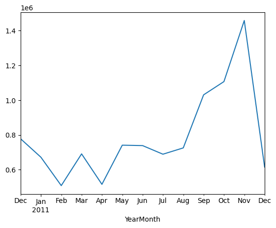

```python
monthly_revenue.plot()
```

##### Monthly Customers Trend

```python
monthly_customers = (
    sales_final
    .groupby('YearMonth')['CustomerID']
    .nunique()
)
```

#### Product Analysis

##### Business Question: Which products drive revenue?

##### Top Products by Revenue

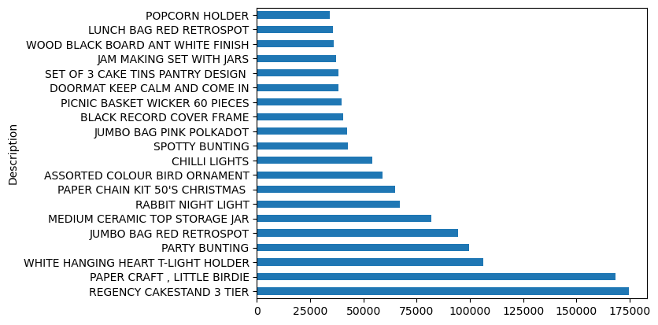

```python
top_products_revenue = (
    sales_final
    .groupby('Description')['Revenue']
    .sum()
    .sort_values(ascending=False)
    .head(20)
)

top_products_revenue.plot.barh()
```

##### Top Products by Quantity Sold

```python
top_products_qty = (
    sales_final
    .groupby('Description')['Quantity']
    .sum()
    .sort_values(ascending=False)
    .head(20)
)

top_products_qty
```

```
Description
PAPER CRAFT , LITTLE BIRDIE           80995
MEDIUM CERAMIC TOP STORAGE JAR        78033
WORLD WAR 2 GLIDERS ASSTD DESIGNS     55047
JUMBO BAG RED RETROSPOT               48474
WHITE HANGING HEART T-LIGHT HOLDER    37891
POPCORN HOLDER                        36761
ASSORTED COLOUR BIRD ORNAMENT         36461
PACK OF 72 RETROSPOT CAKE CASES       36419
RABBIT NIGHT LIGHT                    30788
MINI PAINT SET VINTAGE                26633
PACK OF 12 LONDON TISSUES             26135
PACK OF 60 PINK PAISLEY CAKE CASES    24854
VICTORIAN GLASS HANGING T-LIGHT       24304
ASSORTED COLOURS SILK FAN             23826
BROCADE RING PURSE                    23056
RED  HARMONICA IN BOX                 21933
JUMBO BAG PINK POLKADOT               21465
SMALL POPCORN HOLDER                  20160
PAPER CHAIN KIT 50'S CHRISTMAS        19355
LUNCH BAG RED RETROSPOT               19353
Name: Quantity, dtype: int64
```

##### Product Price Distribution

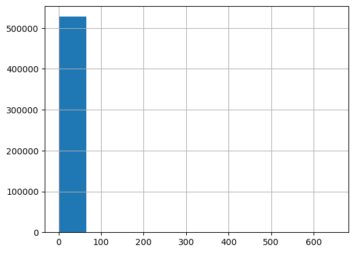

```python
sales_final['UnitPrice'].hist()
```

##### Customer Analysis

```python
customer_df = sales_clean[
    sales_final['CustomerID'].notna()
]

customer_df
```

|  | InvoiceNo | StockCode | Description | Quantity | InvoiceDate | UnitPrice | CustomerID | Country | Revenue |
| --- | --- | --- | --- | --- | --- | --- | --- | --- | --- |
| 0 | 536365 | 85123A | WHITE HANGING HEART T-LIGHT HOLDER | 6 | 2010-12-01 08:26:00 | 2.55 | 17850.0 | United Kingdom | 15.30 |
| 1 | 536365 | 71053 | WHITE METAL LANTERN | 6 | 2010-12-01 08:26:00 | 3.39 | 17850.0 | United Kingdom | 20.34 |
| 2 | 536365 | 84406B | CREAM CUPID HEARTS COAT HANGER | 8 | 2010-12-01 08:26:00 | 2.75 | 17850.0 | United Kingdom | 22.00 |
| 3 | 536365 | 84029G | KNITTED UNION FLAG HOT WATER BOTTLE | 6 | 2010-12-01 08:26:00 | 3.39 | 17850.0 | United Kingdom | 20.34 |
| 4 | 536365 | 84029E | RED WOOLLY HOTTIE WHITE HEART. | 6 | 2010-12-01 08:26:00 | 3.39 | 17850.0 | United Kingdom | 20.34 |
| ... | ... | ... | ... | ... | ... | ... | ... | ... | ... |
| 541904 | 581587 | 22613 | PACK OF 20 SPACEBOY NAPKINS | 12 | 2011-12-09 12:50:00 | 0.85 | 12680.0 | France | 10.20 |
| 541905 | 581587 | 22899 | CHILDREN'S APRON DOLLY GIRL | 6 | 2011-12-09 12:50:00 | 2.10 | 12680.0 | France | 12.60 |
| 541906 | 581587 | 23254 | CHILDRENS CUTLERY DOLLY GIRL | 4 | 2011-12-09 12:50:00 | 4.15 | 12680.0 | France | 16.60 |
| 541907 | 581587 | 23255 | CHILDRENS CUTLERY CIRCUS PARADE | 4 | 2011-12-09 12:50:00 | 4.15 | 12680.0 | France | 16.60 |
| 541908 | 581587 | 22138 | BAKING SET 9 PIECE RETROSPOT | 3 | 2011-12-09 12:50:00 | 4.95 | 12680.0 | France | 14.85 |

396340 rows × 9 columns

##### Top Customers by Revenue

```python
top_customers = (
    customer_df
    .groupby('CustomerID')['Revenue']
    .sum()
    .sort_values(ascending=False)
    .head(20)
)

top_customers
```

```
CustomerID
14646.0    279138.02
18102.0    259657.30
17450.0    194550.79
16446.0    168472.50
14911.0    136275.72
12415.0    124564.53
14156.0    116729.63
17511.0     91062.38
12346.0     77183.60
16029.0     72882.09
16684.0     66653.56
13694.0     65039.62
15311.0     60767.90
13089.0     58825.83
17949.0     58030.48
15769.0     56252.72
15061.0     54534.14
14096.0     53258.43
14298.0     51527.30
14088.0     50491.81
Name: Revenue, dtype: float64
```

##### Purchase Frequency Distribution

Purchase frequency measures how often customers place orders during the period under analysis.

The objective is to understand customer purchasing behavior and determine whether the business relies primarily on one-time buyers or repeat customers.

```python
purchase_frequency = (sales_final.dropna(subset=['CustomerID']).groupby('CustomerID')['InvoiceNo'].nunique())

purchase_frequency.describe()
```

```
count    4334.000000
mean        4.245962
std         7.634989
min         1.000000
25%         1.000000
50%         2.000000
75%         5.000000
max       206.000000
Name: InvoiceNo, dtype: float64
```

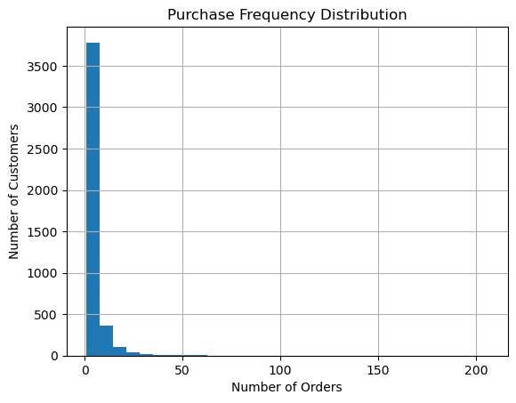

```python
purchase_frequency.hist(bins=30)
plt.title('Purchase Frequency Distribution')
plt.xlabel('Number of Orders')
plt.ylabel('Number of Customers')
plt.show()
```

```python
purchase_frequency.value_counts().sort_index().head(20)
```

```
InvoiceNo
1     1505
2      831
3      502
4      395
5      236
6      173
7      139
8       98
9       69
10      54
11      54
12      43
13      29
14      20
15      26
16       9
17      19
18      13
19      12
20      13
Name: count, dtype: int64
```

```python
#percentage of customers who made exactly one purchase.

(purchase_frequency == 1).mean() * 100
```

```
np.float64(34.72542685740655)
```

### Purchase Frequency Distribution

Customer purchase frequency analysis shows a strongly right-skewed distribution. Approximately 34.7% of customers placed only a single order during the observation period, making one-time purchasers the largest customer segment.

The results suggest that the company may benefit from customer retention initiatives such as loyalty programs, personalized marketing campaigns, and targeted promotions aimed at encouraging repeat purchases.

Increasing repeat purchase behavior could have a substantial impact on revenue growth, as existing customers are often less expensive to retain than acquiring new customers.

##### Customer Spending Distribution

Customer spending analysis measures how much revenue each customer generates over the analysis period.

The objective is to identify high-value customers and understand the distribution of customer spending.

```python
customer_spending = (sales_final.dropna(subset =['CustomerID']).groupby('CustomerID')['Revenue'].sum())

customer_spending.describe()
```

```
count      4334.000000
mean       2021.473616
std        8907.501378
min           3.750000
25%         305.560000
50%         668.125000
75%        1631.622500
max      279138.020000
Name: Revenue, dtype: float64
```

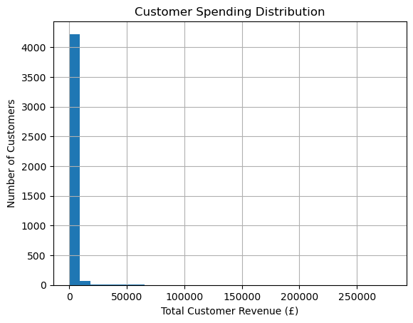

```python
customer_spending.hist(bins=30)
plt.title('Customer Spending Distribution')
plt.xlabel('Total Customer Revenue (£)')
plt.ylabel('Number of Customers')
plt.show()
```

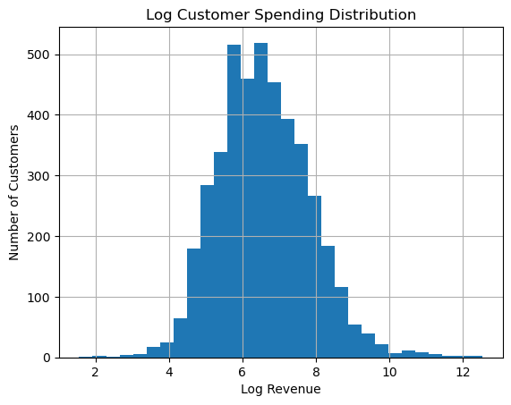

```python
np.log1p(customer_spending).hist(bins=30)
plt.title('Log Customer Spending Distribution')
plt.xlabel('Log Revenue')
plt.ylabel('Number of Customers')
plt.show()
```

#### A strongly right-skewed distribution suggests that a small percentage of customers contribute a disproportionately large share of total revenue, indicating opportunities for customer retention and loyalty programs.

##### Orders per Customer

```python
customer_orders = (
    customer_df
    .groupby('CustomerID')['InvoiceNo']
    .nunique()
)

customer_orders
```

```
CustomerID
12346.0     1
12347.0     7
12348.0     4
12349.0     1
12350.0     1
           ..
18280.0     1
18281.0     1
18282.0     2
18283.0    16
18287.0     3
Name: InvoiceNo, Length: 4334, dtype: int64
```

```python
customer_orders.describe()
```

```
count    4334.000000
mean        4.245962
std         7.634989
min         1.000000
25%         1.000000
50%         2.000000
75%         5.000000
max       206.000000
Name: InvoiceNo, dtype: float64
```

##### Geographic Analysis

##### Revenue by Country

```python
country_revenue = (
    sales_final
    .groupby('Country')['Revenue']
    .sum()
    .sort_values(ascending=False)
)

country_revenue
```

```
Country
United Kingdom          8748247.473
Netherlands              283889.340
EIRE                     271164.300
Germany                  205569.890
France                   184582.740
Australia                138171.310
Spain                     55725.110
Switzerland               53087.900
Japan                     37416.370
Belgium                   36927.340
Sweden                    36839.330
Norway                    32454.640
Portugal                  27015.160
Channel Islands           20007.440
Finland                   18344.880
Denmark                   18211.340
Italy                     15820.240
Cyprus                    13254.690
Hong Kong                  9952.990
Singapore                  9120.390
Austria                    8742.680
Israel                     8135.260
Poland                     6974.650
Unspecified                4749.790
Greece                     4425.520
Iceland                    4310.000
USA                        3580.390
Canada                     3115.440
Malta                      2070.590
United Arab Emirates       1864.780
Lebanon                    1693.880
Lithuania                  1661.060
European Community         1159.250
Brazil                     1143.600
RSA                        1002.310
Czech Republic              786.740
Bahrain                     754.140
Saudi Arabia                145.920
Name: Revenue, dtype: float64
```

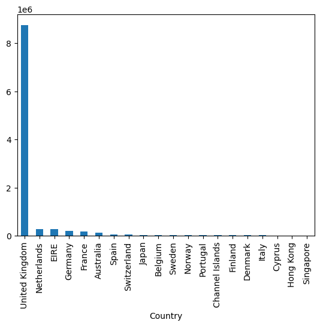

```python
country_revenue.head(20).plot.bar()
```

##### Orders by Country

```python
country_orders = sales_final.groupby('Country')['InvoiceNo'].nunique().sort_values(ascending=False)
```

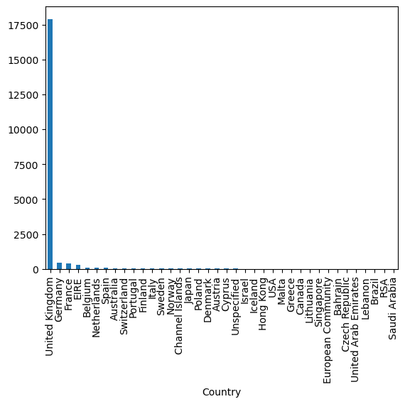

```python
country_orders.plot.bar()
```

##### Domestic vs International Performance

```python
# Create a Market Category

sales_final['Market'] = sales_final['Country'].apply(
    lambda x: 'Domestic'
    if x == 'United Kingdom'
    else 'International'
)
```

##### Revenue Comparison

```python
market_revenue = (
    sales_final
    .groupby('Market')['Revenue']
    .sum()
)

market_revenue
```

```
Market
Domestic         8748247.473
International    1523871.400
Name: Revenue, dtype: float64
```

##### Orders Comparison

```python
market_orders = (
    sales_final
    .groupby('Market')['InvoiceNo']
    .nunique()
)

market_orders
```

```
Market
Domestic         17901
International     1872
Name: InvoiceNo, dtype: int64
```

##### Customer Comparison

```python
market_customers = (
    sales_final
    .groupby('Market')['CustomerID']
    .nunique()
)

market_customers
```

```
Market
Domestic         3916
International     418
Name: CustomerID, dtype: int64
```

##### Average Order Value

```python
market_aov = (
    sales_final
    .groupby('Market')
    .agg(
        Revenue=('Revenue','sum'),
        Orders=('InvoiceNo','nunique')
    )
)

market_aov['AOV'] = (
    market_aov['Revenue']
    / market_aov['Orders']
)

market_aov
```

| Market | Revenue | Orders | AOV |
| --- | --- | --- | --- |
| Domestic | 8748247.473 | 17901 | 488.701607 |
| International | 1523871.400 | 1872 | 814.033868 |

### Domestic vs International Performance

The analysis reveals that the business is heavily dependent on domestic sales within the United Kingdom. Domestic customers generated approximately £8.75 million in revenue from 17,901 orders, accounting for the majority of overall business activity.

In contrast, international customers generated approximately £1.52 million in revenue from 1,872 orders. Although international transactions represent a much smaller proportion of total orders, they exhibit significantly higher spending behavior.

The Average Order Value (AOV) for international customers was approximately £814, compared to £489 for domestic customers. This indicates that international customers tend to place larger orders and contribute more revenue per transaction.

From a business perspective, these findings suggest that while the company's revenue base is primarily supported by the domestic market, international customers represent a high-value customer segment. Strategic investments in international marketing, logistics, and customer acquisition could potentially generate substantial revenue growth due to the higher purchasing power observed among overseas customers.

Overall, the business demonstrates strong domestic market penetration while also showing promising opportunities for international expansion and revenue diversification.

##### Time-Based Analysis

##### Revenue by Day of Week

```python
week_day = sales_final.groupby(
    'DayOfWeek'
)['Revenue'].sum().sort_values(ascending=False)

week_day
```

```
DayOfWeek
Thursday     2135624.270
Tuesday      2088047.421
Wednesday    1786539.310
Friday       1770107.011
Monday       1686452.530
Sunday        805348.331
Name: Revenue, dtype: float64
```

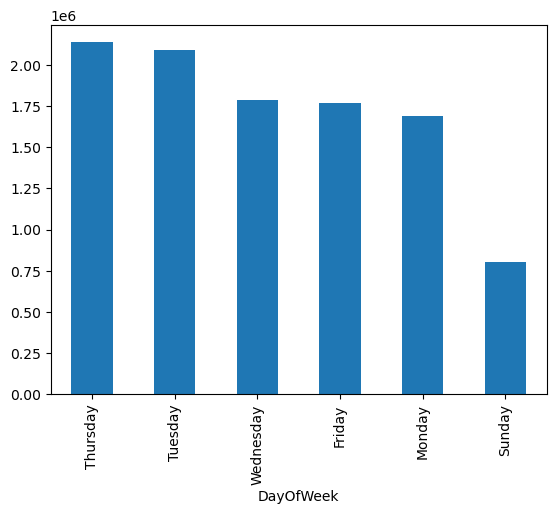

```python
week_day.plot.bar()
```

##### Revenue by Hour

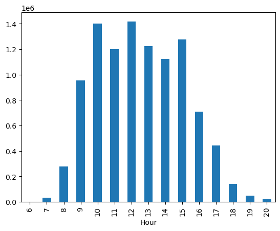

```python
hour_revenue = sales_final.groupby('Hour')['Revenue'].sum()

hour_revenue.plot.bar()
```

##### Revenue by Month

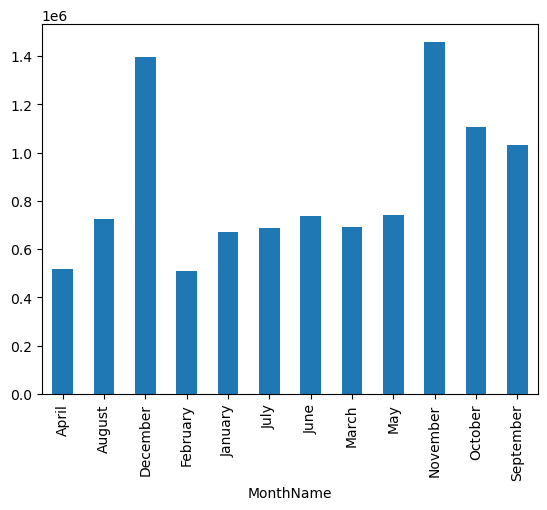

```python
month_revenue = sales_final.groupby('MonthName')['Revenue'].sum()

month_revenue.plot.bar()
```

##### Total Revenue

```python
total_revenue = sales_final['Revenue'].sum()

print(f"Total Revenue: £{total_revenue:,.2f}")
```

```
Total Revenue: £10,272,118.87
```

##### Total Orders

```python
total_orders = sales_final['InvoiceNo'].nunique()

print(f"Total Orders: {total_orders:,}")
```

```
Total Orders: 19,773
```

##### Total Customers

```python
total_customers = sales_final['CustomerID'].nunique()

print(f"Total Customers: {total_customers:,}")
```

```
Total Customers: 4,334
```

##### Total Units Sold

```python
total_units_sold = sales_final['Quantity'].sum()

print(f"Total Units Sold: {total_units_sold:,}")
```

```
Total Units Sold: 5,577,136
```

```python
kpi_summary = pd.DataFrame({
    'Metric': [
        'Total Revenue',
        'Total Orders',
        'Total Customers',
        'Total Units Sold'
    ],
    'Value': [
        sales_final['Revenue'].sum(),
        sales_final['InvoiceNo'].nunique(),
        sales_final['CustomerID'].nunique(),
        sales_final['Quantity'].sum()
    ]
})

kpi_summary
```

|  | Metric | Value |
| --- | --- | --- |
| 0 | Total Revenue | 1.027212e+07 |
| 1 | Total Orders | 1.977300e+04 |
| 2 | Total Customers | 4.334000e+03 |
| 3 | Total Units Sold | 5.577136e+06 |

```python
kpi_summary['Value'] = kpi_summary['Value'].map(
    lambda x: f"{x:,.2f}" if isinstance(x, float) else f"{x:,}"
)

kpi_summary
```

|  | Metric | Value |
| --- | --- | --- |
| 0 | Total Revenue | 10,272,118.87 |
| 1 | Total Orders | 19,773.00 |
| 2 | Total Customers | 4,334.00 |
| 3 | Total Units Sold | 5,577,136.00 |

##### Basket Analysis

##### 1. Average Basket Size

Business Question: How many items does a customer typically purchase in a single transaction?

```python
basket_size = sales_final.groupby('InvoiceNo')['Quantity'].sum()

avg_basket_size = basket_size.mean()

avg_basket_size
```

```
np.float64(282.05816011733174)
```

##### Average Basket Size

Average basket size measures the number of units purchased per transaction and provides insight into customer purchasing behavior.

A relatively large basket size suggests that customers often buy products in bulk quantities, potentially for resale or business use rather than personal consumption.

Understanding basket size helps businesses identify opportunities for cross-selling, product bundling, and inventory planning. Larger baskets generally contribute to higher revenue generation and may indicate stronger customer engagement.

##### 2. Average Invoice Value (Average Order Value)

Business Question: How much revenue does a typical order generate?

```python
invoice_revenue = sales_final.groupby(
    'InvoiceNo'
)['Revenue'].sum()

average_invoice_value = invoice_revenue.mean()

average_invoice_value
```

```
np.float64(519.5022946947857)
```

##### Average Invoice Value

Average Invoice Value (AIV) measures the average revenue generated per transaction and serves as a key indicator of customer spending behavior.

The analysis reveals that the average order generates approximately £519.50 in revenue. This suggests that customers place relatively high-value orders, reinforcing the observation that the business operates primarily within a wholesale retail environment.

A high average invoice value can have a significant positive impact on profitability, as fewer transactions are required to generate substantial revenue. Monitoring this metric over time helps assess changes in customer purchasing patterns and the effectiveness of sales strategies.

The business may further increase average invoice value through product recommendations, volume discounts, and strategic bundling of complementary products.

##### 3. Relationship Between Basket Size and Revenue

Business Question: Do larger baskets generate proportionally higher revenue?

```python
invoice_analysis = sales_final.groupby('InvoiceNo').agg(
    BasketSize=('Quantity','sum'),
    Revenue=('Revenue','sum')
)

invoice_analysis.head()
```

| InvoiceNo | BasketSize | Revenue |
| --- | --- | --- |
| 536365 | 40 | 139.12 |
| 536366 | 12 | 22.20 |
| 536367 | 83 | 278.73 |
| 536368 | 15 | 70.05 |
| 536369 | 3 | 17.85 |

##### Correlation

```python
invoice_analysis[['BasketSize','Revenue']].corr()
```

|  | BasketSize | Revenue |
| --- | --- | --- |
| BasketSize | 1.000000 | 0.891843 |
| Revenue | 0.891843 | 1.000000 |

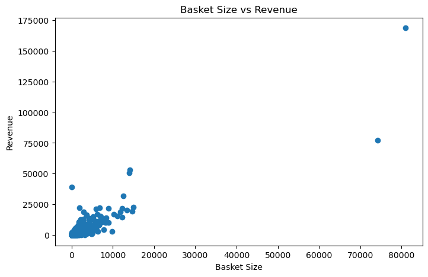

```python
import matplotlib.pyplot as plt

plt.figure(figsize=(8,5))

plt.scatter(
    invoice_analysis['BasketSize'],
    invoice_analysis['Revenue']
)

plt.xlabel('Basket Size')
plt.ylabel('Revenue')
plt.title('Basket Size vs Revenue')

plt.show()
```

##### Relationship Between Basket Size and Revenue

To understand whether customers who purchase more items generate greater revenue, a basket size versus revenue analysis was conducted at the invoice level.

The analysis produced a strong positive correlation of 0.892 between basket size and revenue. This indicates that larger baskets are strongly associated with higher sales value and that the number of items purchased is a major driver of transaction revenue.

The scatter plot further confirms this relationship, showing a clear upward trend as basket size increases. While the relationship is not perfectly linear due to differences in product pricing, customers purchasing larger quantities generally generate substantially higher revenue.

This finding suggests that initiatives aimed at increasing basket size—such as product bundles, quantity discounts, cross-selling, and complementary product recommendations—could have a meaningful impact on overall revenue growth.

From a business perspective, basket expansion represents a valuable opportunity because increasing the number of items purchased per transaction can drive revenue without requiring additional customer acquisition efforts.

##### Seasonal Trends

##### Monthly Revenue Trend

Business Question How does revenue change throughout the year?

```python
monthly_revenue = sales_final.groupby(
    'YearMonth'
)['Revenue'].sum().reset_index()

monthly_revenue
```

|  | YearMonth | Revenue |
| --- | --- | --- |
| 0 | 2010-12 | 778008.360 |
| 1 | 2011-01 | 671992.410 |
| 2 | 2011-02 | 508952.870 |
| 3 | 2011-03 | 691265.940 |
| 4 | 2011-04 | 516309.791 |
| 5 | 2011-05 | 741275.740 |
| 6 | 2011-06 | 738876.880 |
| 7 | 2011-07 | 689397.741 |
| 8 | 2011-08 | 725605.160 |
| 9 | 2011-09 | 1030500.361 |
| 10 | 2011-10 | 1106686.490 |
| 11 | 2011-11 | 1457745.530 |
| 12 | 2011-12 | 615501.600 |

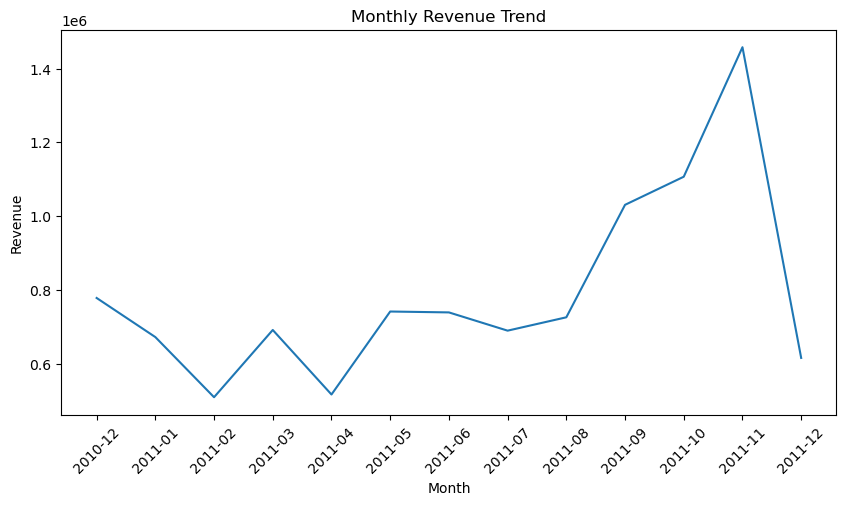

```python
import matplotlib.pyplot as plt

plt.figure(figsize=(10,5))

plt.plot(
    monthly_revenue['YearMonth'].astype(str),
    monthly_revenue['Revenue']
)

plt.xticks(rotation=45)

plt.title('Monthly Revenue Trend')
plt.xlabel('Month')
plt.ylabel('Revenue')

plt.show()
```

##### Monthly Revenue Trend

The monthly revenue analysis reveals clear seasonality in customer purchasing behavior. Revenue remained relatively stable throughout most of 2011, ranging between approximately £509K and £741K per month. However, a significant increase occurred during the final quarter of the year.

Revenue increased from £725.6K in August to £1.03M in September, £1.11M in October, and peaked at £1.46M in November. This represents more than double the revenue generated during several earlier months.

The sharp rise in Q4 suggests strong holiday-season demand, likely driven by Christmas shopping, gift purchases, and year-end promotional activities.

##### Monthly Order Trend

Business Question: Does customer ordering activity follow the same pattern as revenue?

```python
monthly_orders = sales_final.groupby(
    'YearMonth'
)['InvoiceNo'].nunique().reset_index()

monthly_orders
```

|  | YearMonth | InvoiceNo |
| --- | --- | --- |
| 0 | 2010-12 | 1550 |
| 1 | 2011-01 | 1081 |
| 2 | 2011-02 | 1093 |
| 3 | 2011-03 | 1440 |
| 4 | 2011-04 | 1235 |
| 5 | 2011-05 | 1668 |
| 6 | 2011-06 | 1525 |
| 7 | 2011-07 | 1452 |
| 8 | 2011-08 | 1339 |
| 9 | 2011-09 | 1818 |
| 10 | 2011-10 | 2005 |
| 11 | 2011-11 | 2751 |
| 12 | 2011-12 | 816 |

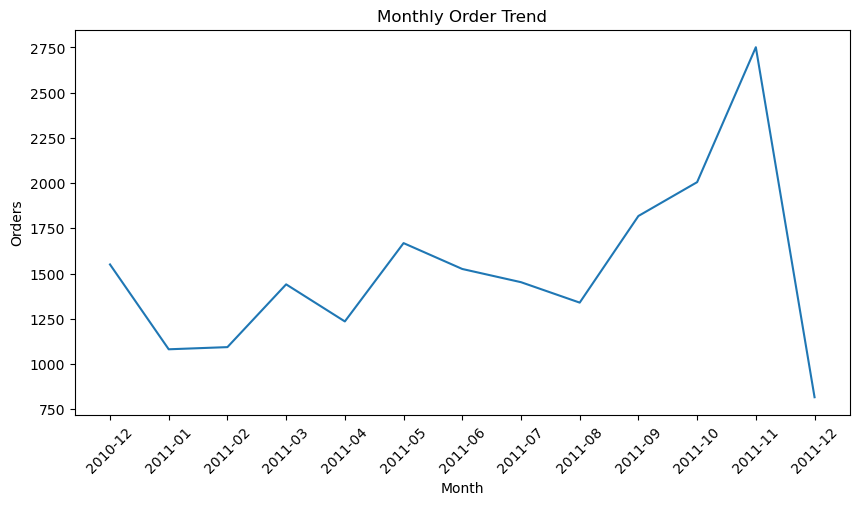

```python
plt.figure(figsize=(10,5))

plt.plot(
    monthly_orders['YearMonth'].astype(str),
    monthly_orders['InvoiceNo']
)

plt.xticks(rotation=45)

plt.title('Monthly Order Trend')
plt.xlabel('Month')
plt.ylabel('Orders')

plt.show()
```

##### Monthly Order Trend

Order volume followed a similar pattern to revenue.

The decline observed in December should be interpreted cautiously because the dataset only contains transactions up to 9 December 2011, making the month incomplete.

##### Peak Shopping Periods

Business Question Which months contribute the most revenue?

```python
sales_final.groupby(
    'MonthName'
)['Revenue'].sum().sort_values(
    ascending=False
)
```

```
MonthName
November     1457745.530
December     1393509.960
October      1106686.490
September    1030500.361
May           741275.740
June          738876.880
August        725605.160
March         691265.940
July          689397.741
January       671992.410
April         516309.791
February      508952.870
Name: Revenue, dtype: float64
```

```python
sales_final.groupby(
    'MonthName'
)['InvoiceNo'].nunique().sort_values(
    ascending=False
)
```

```
MonthName
November     2751
December     2366
October      2005
September    1818
May          1668
June         1525
July         1452
March        1440
August       1339
April        1235
February     1093
January      1081
Name: InvoiceNo, dtype: int64
```

##### Peak Shopping Periods

Analysis of monthly revenue and order volume identifies November as the strongest performing month across the entire dataset.

Key observations include:

- November generated the highest revenue (£1.46M).
- November recorded the highest order volume (2,751 orders).
- October and September also showed strong performance, indicating that holiday shopping activity begins several months before Christmas.
- February and April were the weakest revenue months.

These findings suggest that the retailer's business is highly seasonal, with a significant proportion of annual sales concentrated in the final quarter of the year

##### Business Insight

The business demonstrates strong seasonal purchasing patterns, with sales activity accelerating significantly during the final quarter of the year. November emerged as the most important trading month, generating both the highest revenue and highest order volume. This indicates that holiday-related demand is a major revenue driver and highlights the importance of inventory planning, marketing campaigns, and operational readiness during peak shopping periods. Businesses operating in similar retail environments should prioritize stock availability and customer acquisition efforts ahead of the Q4 shopping season to maximize revenue opportunities.

##### Average Monthly Revenue Growth(%)

```python
monthly_revenue = sales_final.groupby(
    'YearMonth'
)['Revenue'].sum()

# Remove incomplete December 2011
monthly_revenue = monthly_revenue.iloc[:-1]

revenue_growth = monthly_revenue.pct_change() * 100

average_growth = revenue_growth.mean()

average_growth
```

```
np.float64(8.687360156201818)
```

##### Average Monthly Revenue Growth

To evaluate overall business performance, month-over-month revenue growth was calculated using complete trading months only.

The final month in the dataset (December 2011) was excluded from the calculation because it contains transactions for only a partial month, which would artificially distort growth metrics.

The analysis shows an average monthly revenue growth rate of approximately 8.69%, indicating that the business experienced overall positive sales momentum during the observed period.

Although growth fluctuated throughout the year, strong performance during September, October, and November contributed significantly to overall expansion, reinforcing the importance of the retailer's peak seasonal period.

##### Pareto Analysis (80/20 Rule)

Business Question

What percentage of customers generate most of the revenue?

##### Customer Revenue

```python
customer_revenue = (
    sales_final
    .groupby('CustomerID')['Revenue']
    .sum()
    .sort_values(ascending=False)
)

customer_revenue.head()
```

```
CustomerID
14646.0    279138.02
18102.0    259657.30
17450.0    194550.79
16446.0    168472.50
14911.0    136275.72
Name: Revenue, dtype: float64
```

##### Business Question

What percentage of customers generate most of the company's revenue?

This analysis applies the Pareto Principle, which suggests that a relatively small proportion of customers often generate a large proportion of revenue.

Interpretation

The analysis shows that a relatively small percentage of customers are responsible for generating the majority of total revenue. This indicates that revenue concentration exists within the customer base, meaning the business relies heavily on a core group of high-value customers.

From a business perspective, this is common in retail environments and highlights the importance of:

- Retaining high-value customers.
- Developing loyalty programs.
- Providing personalized offers and promotions.
- Monitoring customer churn among top spenders.

The result confirms that not all customers contribute equally to revenue generation, making customer-focused strategies critical for sustainable growth.

Business Insight:

- The company should prioritize customer retention efforts for its highest-spending customers because losing a small number of these customers could have a significant impact on overall revenue performance.

##### Calculate Revenue Contribution

```python
pareto = customer_revenue.reset_index()

pareto.columns = [
    'CustomerID',
    'Revenue'
]

pareto['RevenuePct'] = (
    pareto['Revenue']
    /
    pareto['Revenue'].sum()
)

pareto['CumulativeRevenuePct'] = (
    pareto['RevenuePct']
    .cumsum()
)
```

##### Find Customers Responsible for 80% of Revenue

```python
customers_80 = (
    pareto['CumulativeRevenuePct'] <= 0.80
).sum()

total_customers = pareto['CustomerID'].nunique()

customer_percentage = (
    customers_80
    /
    total_customers
) * 100

customer_percentage
```

```
np.float64(26.18827872634979)
```

#### RFM Segmentation

##### Reference Date

```python
snapshot_date = (
    sales_final['InvoiceDate'].max()
    + pd.Timedelta(days=1)
)

snapshot_date
```

```
Timestamp('2011-12-10 12:50:00')
```

##### Build RFM Table

```python
rfm = sales_final.groupby(
    'CustomerID'
).agg({

    'InvoiceDate':
    lambda x: (
        snapshot_date - x.max()
    ).days,

    'InvoiceNo':
    'nunique',

    'Revenue':
    'sum'

})

rfm.columns = [
    'Recency',
    'Frequency',
    'Monetary'
]

rfm.head()
```

| CustomerID | Recency | Frequency | Monetary |
| --- | --- | --- | --- |
| 12346.0 | 326 | 1 | 77183.60 |
| 12347.0 | 2 | 7 | 4310.00 |
| 12348.0 | 75 | 4 | 1437.24 |
| 12349.0 | 19 | 1 | 1457.55 |
| 12350.0 | 310 | 1 | 294.40 |

##### Create Scores

```python
rfm['R_Score'] = pd.qcut(
    rfm['Recency'],
    4,
    labels=[4,3,2,1]
)

rfm['F_Score'] = pd.qcut(
    rfm['Frequency'].rank(method='first'),
    4,
    labels=[1,2,3,4]
)

rfm['M_Score'] = pd.qcut(
    rfm['Monetary'],
    4,
    labels=[1,2,3,4]
)
```

##### Combined RFM Score

```python
rfm['RFM_Score'] = (
    rfm['R_Score'].astype(str)
    +
    rfm['F_Score'].astype(str)
    +
    rfm['M_Score'].astype(str)
)
```

##### Segment Customers

```python
def segment_customer(row):

    if row['RFM_Score'] == '444':
        return 'Champions'

    elif row['R_Score'] >= 3 and row['F_Score'] >= 3:
        return 'Loyal Customers'

    elif row['R_Score'] <= 2 and row['F_Score'] >= 3:
        return 'At Risk'

    else:
        return 'Lost Customers'


rfm['Segment'] = (
    rfm.apply(
        segment_customer,
        axis=1
    )
)
```

##### Segment Distribution

```python
rfm['Segment'].value_counts()
```

```
Segment
Lost Customers     2167
Loyal Customers    1027
At Risk             643
Champions           497
Name: count, dtype: int64
```

##### Business Question

Who are the company's best customers?

RFM (Recency, Frequency, Monetary) segmentation classifies customers based on:

- Recency → How recently they purchased.
- Frequency → How often they purchase.
- Monetary → How much they spend.

This helps identify customer value and engagement levels.

Interpretation

The largest customer segment consists of Lost Customers (2,167 customers), indicating that many customers have not made a recent purchase.

Only 497 customers qualify as Champions, representing the most valuable customers who purchase frequently, spend significantly, and remain highly engaged.

The presence of over 1,000 Loyal Customers suggests a strong foundation of repeat buyers who could potentially be nurtured into Champion customers through targeted engagement strategies.

Business Insight: The business appears effective at acquiring customers but faces opportunities to improve long-term retention and customer reactivation.

##### Revenue by Segment

```python
rfm.groupby(
    'Segment'
)['Monetary'].agg(
    ['count','sum','mean']
)
```

| Segment | count | sum | mean |
| --- | --- | --- | --- |
| At Risk | 643 | 1011886.370 | 1573.695754 |
| Champions | 497 | 4395220.130 | 8843.501268 |
| Lost Customers | 2167 | 1262541.972 | 582.622045 |
| Loyal Customers | 1027 | 2091418.181 | 2036.434451 |

##### Interpretation

The Champions segment generated approximately £4.40 million in revenue, making it the most valuable customer group despite being the smallest segment.

Each Champion customer generated an average of approximately £8,844, which is more than four times the average revenue generated by Loyal Customers and over fifteen times that of Lost Customers.

Although Lost Customers represent the largest segment by customer count, their average revenue contribution is relatively low, indicating reduced engagement and purchasing activity.

Key Business Findings Champions

- Highest revenue-generating segment.
- Most engaged and profitable customers.
- Strong candidates for VIP programs and exclusive offers.

Recommendation: Focus on retention strategies and personalized experiences to maintain loyalty.

Loyal Customers

- Consistent repeat buyers.
- Significant revenue contribution.
- Potential future Champions.

Recommendation: Encourage higher spending through cross-selling, upselling, and loyalty rewards.

At Risk Customers

- Previously valuable customers showing declining activity.
- Still contribute meaningful revenue.

Recommendation: Implement targeted win-back campaigns before these customers become inactive.

Lost Customers

- Largest customer segment.
- Lowest revenue contribution per customer.
- Limited recent engagement.

Recommendation: Assess whether reactivation efforts are cost-effective. Focus primarily on high-value lost customers rather than the entire segment.

##### The RFM analysis reveals that customer value is highly concentrated among a relatively small group of customers. While Champions account for only a small portion of the customer base, they generate the largest share of revenue and represent the company's most strategically important customers.

The business should focus on:

- Protecting Champion customers through retention initiatives.
- Converting Loyal Customers into Champions.
- Re-engaging At Risk customers before churn occurs.
- Selectively reactivating high-value Lost Customers.

This analysis demonstrates how customer segmentation can move beyond descriptive reporting and directly support revenue growth, customer retention, and marketing strategy decisions.

##### Cohort Analysis

##### Business Question

How well does the business retain customers?

```python
#Create a separate dataframe:

cohort_df = sales_final[
    sales_final['CustomerID'].notna()
].copy()
```

```python
#create cohort month
first_purchase = (
    cohort_df.groupby('CustomerID')
    ['InvoiceDate']
    .min()
)
```

```python
cohort_df['CohortMonth'] = (
    cohort_df['CustomerID']
    .map(first_purchase.dt.to_period('M'))
)
```

```python
#create purchase month
cohort_df['PurchaseMonth'] = (
    cohort_df['InvoiceDate']
    .dt.to_period('M')
)
```

```python
#cohort index
cohort_df['CohortIndex'] = (
    cohort_df['PurchaseMonth']
    -
    cohort_df['CohortMonth']
).apply(lambda x: x.n)
```

```python
# build cohort table

cohort_data = cohort_df.groupby(
    ['CohortMonth', 'CohortIndex']
)['CustomerID'].nunique().reset_index()
```

```python
#create cohort matrix

cohort_counts = cohort_data.pivot(
    index='CohortMonth',
    columns='CohortIndex',
    values='CustomerID'
)
```

```python
#Calculate Retention Rates


cohort_sizes = cohort_counts.iloc[:, 0]

retention = cohort_counts.divide(
    cohort_sizes,
    axis=0
)

retention = retention.round(3) * 100
```

```python
retention
```

| CohortIndex CohortMonth | 0 | 1 | 2 | 3 | 4 | 5 | 6 | 7 | 8 | 9 | 10 | 11 | 12 |
| --- | --- | --- | --- | --- | --- | --- | --- | --- | --- | --- | --- | --- | --- |
| 2010-12 | 100.0 | 36.5 | 32.4 | 38.3 | 36.2 | 39.8 | 36.2 | 34.8 | 35.3 | 39.5 | 37.3 | 50.2 | 26.5 |
| 2011-01 | 100.0 | 21.9 | 26.7 | 22.8 | 31.7 | 28.8 | 24.8 | 24.0 | 29.6 | 32.7 | 36.5 | 11.8 | NaN |
| 2011-02 | 100.0 | 18.7 | 18.7 | 28.7 | 27.1 | 24.5 | 25.5 | 27.4 | 24.7 | 30.5 | 6.8 | NaN | NaN |
| 2011-03 | 100.0 | 14.8 | 25.2 | 19.9 | 22.3 | 16.8 | 26.8 | 23.0 | 27.9 | 8.6 | NaN | NaN | NaN |
| 2011-04 | 100.0 | 21.0 | 20.3 | 21.0 | 19.7 | 22.7 | 21.7 | 26.0 | 7.3 | NaN | NaN | NaN | NaN |
| 2011-05 | 100.0 | 19.0 | 17.3 | 17.3 | 20.8 | 23.2 | 26.4 | 9.5 | NaN | NaN | NaN | NaN | NaN |
| 2011-06 | 100.0 | 17.4 | 15.7 | 26.4 | 23.1 | 33.1 | 9.5 | NaN | NaN | NaN | NaN | NaN | NaN |
| 2011-07 | 100.0 | 17.6 | 20.3 | 22.5 | 27.3 | 11.2 | NaN | NaN | NaN | NaN | NaN | NaN | NaN |
| 2011-08 | 100.0 | 20.1 | 24.3 | 24.3 | 12.4 | NaN | NaN | NaN | NaN | NaN | NaN | NaN | NaN |
| 2011-09 | 100.0 | 23.4 | 30.1 | 11.4 | NaN | NaN | NaN | NaN | NaN | NaN | NaN | NaN | NaN |
| 2011-10 | 100.0 | 23.5 | 11.5 | NaN | NaN | NaN | NaN | NaN | NaN | NaN | NaN | NaN | NaN |
| 2011-11 | 100.0 | 11.1 | NaN | NaN | NaN | NaN | NaN | NaN | NaN | NaN | NaN | NaN | NaN |
| 2011-12 | 100.0 | NaN | NaN | NaN | NaN | NaN | NaN | NaN | NaN | NaN | NaN | NaN | NaN |

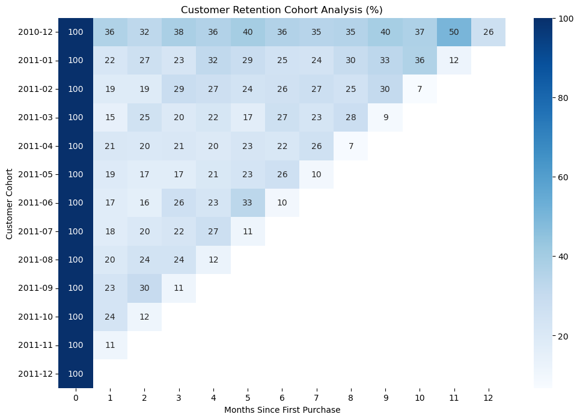

```python
import matplotlib.pyplot as plt
import seaborn as sns

plt.figure(figsize=(12,8))

sns.heatmap(
    retention,
    annot=True,
    fmt='.0f',
    cmap='Blues'
)

plt.title('Customer Retention Cohort Analysis (%)')
plt.xlabel('Months Since First Purchase')
plt.ylabel('Customer Cohort')

plt.show()
```

##### Cohort Analysis: Customer Retention

Business Question

How well does the business retain customers over time after their first purchase?

Customer retention is one of the most important indicators of long-term business sustainability. While acquiring new customers drives growth, retaining existing customers is often more cost-effective and contributes significantly to profitability.

To evaluate retention performance, customers were grouped into cohorts based on the month of their first purchase. Retention rates were then calculated to determine the percentage of customers who returned and made purchases in subsequent months.

Key Findings

The retention matrix reveals that customer retention declines after the initial purchase month, which is expected in most retail businesses.

The December 2010 cohort demonstrates the strongest long-term retention performance. Approximately 36.5% of customers returned in the month following their first purchase, and retention remained relatively stable between 30% and 40% throughout much of the year. Remarkably, over 50% of the original cohort returned during Month 11, likely reflecting seasonal holiday purchasing behavior.

Most cohorts exhibit a significant drop-off after the first month. For example:

- January 2011 retained 21.9% of customers after one month.
- February 2011 retained 18.7% after one month.
- March 2011 retained 14.8% after one month.
- June 2011 retained 17.4% after one month.

Across most cohorts, first-month retention generally falls within the 15%–25% range, indicating that a large proportion of customers purchase only once and do not immediately return.

Retention rates tend to fluctuate in later months, with some cohorts showing temporary increases. These spikes may be driven by seasonal demand, promotional campaigns, holiday shopping periods, or customers making periodic bulk purchases rather than purchasing consistently every month.

Business Interpretation

The analysis suggests that the business successfully acquires new customers but experiences substantial customer attrition after the first purchase.

This finding aligns with earlier analyses showing that:

- Approximately 34.7% of customers purchased only once.
- Revenue is heavily concentrated among a relatively small group of high-value customers.
- Champions and Loyal Customers contribute a disproportionately large share of total revenue.

The combination of low early retention and strong revenue concentration indicates that customer loyalty is a major driver of business performance. Improving repeat purchase behavior could significantly increase revenue without requiring additional customer acquisition spending.

##### Strategic Recommendations

To improve customer retention, the business could consider:

1. Post-Purchase Engagement
- Follow-up emails after first purchases.
- Product recommendations based on previous orders.
- Personalized offers to encourage second purchases.
2. Customer Loyalty Programs
- Reward repeat purchases.
- Introduce points-based incentives.
- Provide exclusive discounts for returning customers.
3. Reactivation Campaigns
- Target At-Risk and Lost Customers identified through RFM segmentation.
- Offer tailored promotions to encourage re-engagement.
4. Seasonal Retention Strategies
- Capitalize on strong holiday purchasing behavior.
- Launch campaigns before peak shopping periods to encourage repeat purchases.

#### KPI TABLE

```python
kpi_table = pd.DataFrame({
    'KPI': [
        'Total Revenue',
        'Total Orders',
        'Total Customers',
        'Average Order Value',
        'Average Monthly Revenue Growth (%)'
    ],
    'Value': [
        round(total_revenue, 2),
        total_orders,
        total_customers,
        round(average_invoice_value, 2),
        round(average_growth, 2)
    ]
})

kpi_table
```

|  | KPI | Value |
| --- | --- | --- |
| 0 | Total Revenue | 10272118.87 |
| 1 | Total Orders | 19773.00 |
| 2 | Total Customers | 4334.00 |
| 3 | Average Order Value | 519.50 |
| 4 | Average Monthly Revenue Growth (%) | 8.69 |

##### KPI Interpretation

Business KPI Summary

To provide a high-level overview of business performance, several key performance indicators (KPIs) were calculated from the cleaned transaction dataset.

The Average Order Value (AOV) was approximately £519.50, indicating that each completed transaction generated substantial revenue on average. This suggests customers frequently purchased multiple products within a single order, consistent with the basket analysis findings.

Monthly revenue exhibited an average growth rate of approximately 8.69%, demonstrating overall positive business growth despite fluctuations throughout the year. Revenue growth accelerated significantly during the final quarter, particularly in September through November, reflecting strong seasonal demand and holiday purchasing activity.

These KPIs provide an executive-level view of the business and establish the foundation for deeper customer, product, and retention analyses conducted throughout this project.

#### Final Conclusion

The business demonstrates strong revenue performance, healthy seasonal growth, and a valuable core group of loyal customers. However, the analysis also reveals significant opportunities to improve customer retention and expand international sales. By focusing on loyalty, reactivation, and basket growth strategies, the business can increase customer lifetime value, strengthen long-term profitability, and achieve more sustainable revenue growth